# Análisis similitud de contenidos y coordinación entre asignaturas

Grado de Ciencias Ambientales. UCO. Curso 25-26

Autor/a

Curro Bonet-García. Profesor de la UCO.

Fecha de publicación

03 de Junio de 2026

# 1 Introducción y objetivos

El objetivo de este informe es evaluar de manera cuantitativa las relaciones semánticas que hay entre las asignaturas del grado de Ciencias Ambientales tal y como se describen en las guías docentes oficiales. Los resultados obtenidos pueden usarse para mejorar la coordinación de la impartición de contenidos en dicho grado.

# 2 Metodología

La metodología propuesta se basa en técnicas de minería de texto y análisis de similitud del texto contenido en las guías docentes. Implica, en términos generales, los siguientes pasos:

1. Descarga automática de las guías docentes oficiales en formato PDF desde el sitio web de la UCO.
2. Extracción y preprocesamiento de las cadenas de texto consideradas como útiles para evaluar la similitud de contenidos (ej. descripción de la asignatura, contenidos teóricos, prácticos, etc.)
3. Identificación semiautomática de las relaciones explícitas entre asignaturas. Se buscan las referencias cruzadas de nombres de asignaturas en las guías docentes. Por ejemplo, si en la guía docente de la asignatura A se dice explícitamente que la docencia está coordinada con la asignatura B, se contabiliza como un evento de coordinación real.
4. Cálculo de índices de similitud literal (IF-IDF) y considerando sinonimias (LSA) entre cada combinación de asignaturas. Es decir, se compara el contenido de todas las asignaturas dos a dos y se asignan dos índices (IF-IDF y LSA) a cada relación.
5. Catalogación de las relaciones identificadas en uno de los siguientes cuatro tipos:

   5.1 **Candidatas a estar experimentando solapamiento horizontal**. Son relaciones en las que se detecta una alta similitud de contenidos y se imparten en el mismo cuatrimestre.

   5.2 **Candidatas a estar experimentando solapamiento vertical**. Son relaciones en las que se detecta una alta similitud de contenidos y se imparten en distintos cuatrimestres o cursos.

   5.3 **Candidatas a tener relaciones instrumentales**. Son relaciones en las que una asignatura hace referencia explícita a otra como requisito o recomendación.

   5.4 **Candidatas a tener miradas transdisciplinares**. Son relaciones en las que las asignaturas involucradas abordan aspectos de la realidad similares (Ej. suelo), pero con enfoques disciplinares diferentes (ej. microbiología y ecología).
6. Análisis de resultados y propuestas de mejora.

Este documento muestra el procedimiento seguido tras aplicar la metodología anterior. Es un documento ejecutable y reproducible en R. Los detalles metodológicos de cada uno de los pasos descritos anteriormente, se muestran en las siguientes secciones.

**Requisitos previos de ejecución**

Para ejecutar el siguiente flujo de trabajo en un entorno local de RStudio, es necesario contar con las librerías `tidyverse` y `rvest` previamente instaladas en el sistema a través de la consola de R empleando el comando `install.packages(c("tidyverse", "tidygraph", "tidytext", "rvest", "ggraph","tm" ))`.

## 2.1 Descarga automática de guías docentes

El análisis de la estructura curricular del Grado en Ciencias Ambientales se basa en la información contenida en las guías docentes oficiales de la Universidad de Córdoba (UCO) para el curso académico 2025-2026.

Para garantizar la reproducibilidad de la auditoría y mitigar los sesgos derivados de la recolección manual de datos, se ha implementado un procedimiento de raspado web (*web scraping*) y descarga masiva automatizada. El siguiente bloque de código accede al catálogo oficial de la Facultad de Ciencias, indexa los enlaces hipertextuales de los documentos PDF correspondientes a la última versión en castellano y los almacena en el entorno local de trabajo.

Durante su ejecución se observan algunos errores. Hay algunos documentos que, aunque constan como PDFs en la web, no lo son.

**Mostrar líneas de código R**

```r
# ==============================================================================
# Establecimiento de rutas de trabajo y directorios de destino
# ==============================================================================

# Creamos la ruta de destino de forma relativa para garantizar que funcione en cualquier PC
output_dir <- file.path("guias")

if (!dir.exists(output_dir)) {
  dir.create(output_dir, recursive = TRUE)
}

# ==============================================================================
# Carga de paquetes necesarios
# ==============================================================================
library(tidyverse)
library(rvest)

# ==============================================================================
# Extracción y filtrado de enlaces de la web de la UCO
# ==============================================================================
url_catalogo <- "https://www.uco.es/ciencias/es/planificacion-ensenanza-ambientales"

webpage <- read_html(url_catalogo)

enlaces <- webpage %>%
  html_nodes("a") %>%
  html_attr("href")

# Aislamiento de documentos PDF específicos del curso 2025-26 en castellano
enlaces_pdf <- enlaces %>%
  keep(~ str_detect(.x, "(?i)\\.pdf$")) %>%
  keep(~ str_detect(.x, "es_2025-26")) %>%
  na.omit()

# Estandarización de URLs hacia protocolo seguro absoluto
enlaces_finales <- if_else(
  str_starts(enlaces_pdf, "http"),
  str_replace(enlaces_pdf, "^http://", "https://"),
  paste0("https://www.uco.es", enlaces_pdf)
) %>% unique()

# ==============================================================================
# Ingesta de datos con detección de errores y descarga masiva de pdfs
# ==============================================================================
nombres_destinos <- file.path(output_dir, basename(enlaces_finales))

walk2(enlaces_finales, nombres_destinos, ~ {
  cat("Descargando archivo:", basename(.x), "\n")
  tryCatch({
    # Se utiliza el método nativo por defecto para maximizar portabilidad multiplataforma
    download.file(.x, destfile = .y, mode = "wb", quiet = TRUE)
    Sys.sleep(0.5) # Pausa de cortesía estructural para evitar denegaciones de servicio
  }, error = function(e) {
    message("Fallo crítico en la descarga del documento: ", basename(.x))
  })
})

cat("Proceso de ingesta finalizado. Archivos almacenados en la ruta relativa:", output_dir, "\n")
```

Tras el proceso anterior, borrar manualmente el archivo llamado `286100es_2025-26.pdf`. Se trata de la guía docente de las prácticas en empresa. Dicha asignatura no tiene contenidos propios, por lo que no tiene sentido incluirla en este análisis.

## 2.2 Extracción textual y normalización del corpus

El siguiente paso, una vez descargados los archivos de las guías docentes, consiste en desestructurar los archivos PDF para crear una base de datos relacional homogénea. Se extraen de forma síncrona los metadatos administrativos (código, curso y cuatrimestre). También se extraen varias secciones cuyo contenido que servirá para el análisis semántico propiamente dicho.

**Mostrar líneas de código R**

```r
# ==============================================================================
# Carga de paquetes y control de rutas relativas
# ==============================================================================

library(pdftools)
library(tidyverse)
library(quanteda)

carpeta_pdfs <- file.path("guias")
archivos_pdf <- list.files(carpeta_pdfs, pattern = "\\.pdf$", full.names = TRUE)
```

## 2.3 Creación de tabla con nombres de asignaturas, sus códigos y sus siglas.

Este paso es importante y no automático. Los nombres de las asignaturas suelen ser largos. Eso hace que su visualización en gráficas no siempre sea fácil. Por eso es preferible usar la abreviatura de la asignatura para dichas visualizaciones. En el horario oficial de la Facultad de Ciencias de la UCO hay ya una lista de abreviaturas para cada asignatura. No he encontrado una forma fácil de automatizar el proceso de descarga de las siglas de cada asignaturas, así que se procede así:

- Visitar la web de los horarios ([esta](https://www.uco.es/ciencias/es/planificacion-ensenanza-ambientales)).
- Ir copiando los nombres, códigos y siglas de las asignaturas de cada curso y cuatrimestre.
- Ir pegando los resultados incrementalmente en un archivo markdown o en un excel directamente.
- Exportar el contenido a un archivo `.csv` y guardarlo en la carpeta `datos_control` con el nombre `codigos_nombres_siglas_asignaturas_web.csv`.

La siguiente línea de código crea el objeto que será usado a continuación para importar el archivo csv mencionado.

**Mostrar líneas de código R**

```r
# ==============================================================================
# Carga en R de archivo csv obtenido de los horarios oficiales.
# ==============================================================================

siglas_nombres_asignaturas <- file.path("datos_control",
                                        "codigos_nombres_siglas_asignaturas_web.csv")
```

## 2.4 Extracción de texto, normalización y creación de corpus unificado

El siguiente paso implica la lectura secuencial de todos los archivos pdf de las guías docentes para extraer de ellos la siguiente información:

- Breve descripción de los contenidos: Esta sección describe muy sucintamente en qué consiste la asignatura en cuestión.
- Conocimientos previos necesarios: Consta de “requisitos previos establecidos en el plan de estudios” y de “recomendaciones”. Esta información se usará para identificar relaciones de dependencia explícitas entre asignaturas.
- Contenidos teóricos: Se trata de la parte de la guía docente que describe los contenidos teóricos que se imparten en la asignatura.
- Contenidos prácticos: Se trata de la parte de la guía docente que describe los contenidos prácticos que se imparten en la asignatura.

El resultado de esta fase se puede ver aquí

**Mostrar líneas de código R**

```r
# ==============================================================================
# Se inicia el bucle de extracción de texto de las guías
# ==============================================================================

datos_guias_inicial <- purrr::map_df(archivos_pdf, function(ruta) {

  # 1. LECTURA VECTORIAL POR PÁGINAS (Preservamos los saltos de línea con \n)
  texto_paginas <- pdftools::pdf_text(ruta)
  texto_completo <- paste(texto_paginas, collapse = "\n")

  # ============================================================================
  # Extracción de metadatos básicos de cada asignatura
  # ============================================================================
  pos_asig <- str_locate(texto_completo, "(?i)Denominación:")[1, "end"]
  asig_val <- if(!is.na(pos_asig)) {
    str_sub(texto_completo, start = pos_asig + 1, end = pos_asig + 150) %>%
      str_split("(?i)Código:") %>% .[[1]] %>% .[1] %>% str_replace_all("\\s+", " ") %>% str_trim()
  } else { NA_character_ }

  pos_cod <- str_locate(texto_completo, "(?i)Código:")[1, "end"]
  cod_val <- if(!is.na(pos_cod)) {
    str_sub(texto_completo, start = pos_cod + 1, end = pos_cod + 30) %>%
      str_extract("\\d+") %>% str_trim()
  } else { NA_character_ }

  pos_curso <- str_locate(texto_completo, "(?i)Curso:")[1, "end"]
  curso_val <- if(!is.na(pos_curso)) {
    str_sub(texto_completo, start = pos_curso + 1, end = pos_curso + 20) %>%
      str_extract("\\d+") %>% as.numeric()
  } else { NA_real_ }

  pos_duracion <- str_locate(texto_completo, "(?i)Duración:")[1, "end"]
  cuat_val <- if(!is.na(pos_duracion)) {
    str_sub(texto_completo, start = pos_duracion + 1, end = pos_duracion + 60) %>%
      str_replace_all("\\s+", " ") %>% str_trim() %>%
      str_extract("^\\w+\\s+\\w+")
  } else { NA_character_ }

  # ============================================================================
  # Extracción de secciones específicas (Enfoque de Filtrado por Línea de Plantilla Web)
  # ============================================================================
  recortar_seccion <- function(texto, baliza_inicio, baliza_fin) {

    # Separamos el texto en líneas reales e independientes
    lineas_crudas <- unlist(strsplit(texto, "\\r?\\n"))

    # Patrones fijos que inyecta de forma automatizada la aplicación web en los pies de página
    patrones_ruido_web <- c("CURSO 2025/26", "CURSO 2026/27", "PÁG\\.", "GUÍA DOCENTE")

    # Eliminamos cualquier línea que contenga trazas de la plantilla de control
    lineas_saneadas <- lineas_crudas[!base::sapply(lineas_crudas, function(linea) {
      any(stringr::str_detect(linea, regex(patrones_ruido_web, ignore_case = TRUE)))
    })]

    # Reconstruimos el bloque operativo de la guía
    texto_purgado <- paste(lineas_saneadas, collapse = "\n")

    # Aplicación de las balizas sobre el texto limpio de ruido institucional
    ini <- str_locate(texto_purgado, regex(baliza_inicio, ignore_case = TRUE))[1, "end"]
    fin <- str_locate(texto_purgado, regex(baliza_fin, ignore_case = TRUE))[1, "start"]

    if (!is.na(ini) & !is.na(fin) & (fin > ini)) {
      # Devolvemos la sección colapsando los espacios múltiples solo al final del proceso
      return(str_sub(texto_purgado, start = ini + 1, end = fin - 1) %>%
               str_replace_all("\\s+", " ") %>% str_trim())
    } else {
      return(NA_character_)
    }
  }

  # Secciones de contenidos y requisitos sin interferencias
  req_val  <- recortar_seccion(texto_completo,
                               "Requisitos previos establecidos en el plan de estudios",
                               "Recomendaciones")
  reco_val <- recortar_seccion(texto_completo, "Recomendaciones", "Programa de la asignatura")

  desc_cont <- recortar_seccion(texto_completo, "Breve descripción de los contenidos",
                                "Conocimientos previos necesarios")
  cont_teor <- recortar_seccion(texto_completo, "1\\. Contenidos teóricos",
                                "2\\. Contenidos prácticos")
  cont_prac <- recortar_seccion(texto_completo, "2\\. Contenidos prácticos",
                                "Bibliografía")

  tibble(
    archivo                = basename(ruta),
    nombre_asignatura      = asig_val,
    codigo                 = cod_val,
    curso                  = curso_val,
    cuatrimestre           = cuat_val,
    requisitos             = req_val,
    recomenda              = reco_val,
    descripcion_contenidos = desc_cont,
    contenidos_teoricos    = cont_teor,
    contenidos_practicos   = cont_prac
  )
})

# ==============================================================================
# Integración de siglas y códigos con nombres de asignaturas
# ==============================================================================
if (file.exists(siglas_nombres_asignaturas)) {
  diccionario_siglas <- read_csv2(siglas_nombres_asignaturas, show_col_types = FALSE) %>%
    rename_all(tolower) %>%
    mutate(
      codigo_clean = as.character(str_extract(codigo, "\\d+")),
      sigla_clean  = str_trim(as.character(sigla))
    ) %>%
    filter(!is.na(codigo_clean) & !is.na(sigla_clean)) %>%
    distinct(codigo_clean, sigla_clean)

  datos_guias <- datos_guias_inicial %>%
    left_join(diccionario_siglas, by = c("codigo" = "codigo_clean")) %>%
    mutate(sigla = if_else(is.na(sigla_clean), codigo, sigla_clean)) %>%
    select(-sigla_clean)
} else {
  datos_guias <- datos_guias_inicial %>% mutate(sigla = codigo)
  cat("Advertencia: No se encontró el archivo CSV de siglas. Usando códigos como identificador.\n")
}

# ==============================================================================
# Consolidación del corpus
# ==============================================================================
corpus_busqueda <- datos_guias %>%
  filter(!is.na(nombre_asignatura)) %>%
  mutate(
    texto_unificado = tolower(paste(coalesce(descripcion_contenidos, ""),
                                    coalesce(contenidos_teoricos, ""),
                                    coalesce(contenidos_practicos, ""), sep = " ")),
    nombre_limpio   = tolower(str_trim(nombre_asignatura))
  )
```

## 2.5 Identificación semiautomática de procesos de coordinación explícitos

El primer paso una vez que se ha construido el Corpus de conocimiento, es identificar los actos de coordinación explícitos que hay en el grado.

Consideramos que hay coordinación real cuando en una guía docente se menciona explícitamente el nombre de otra asignatura. Esta condición debe de cumplirse o bien en la sección de “contenidos teóricos” o en la de “contenidos prácticos”. Asumimos que esto es coordinación explícita porque la mención de asignaturas en las secciones de contenidos implican que hay una relación directa entre las asignaturas. Es decir, sus contenidos están tan integrados que los profesores consideran importante hacer menciones a otras asignaturas cuando explican los contenidos de la suya.

Para identificar automáticamente estas relaciones, procedemos de la siguiente forma:

- Generamos una tabla con los nombres de las asignaturas.
- Buscamos en las secciones de contenidos de las guías docentes los nombres de las asignaturas.
- Se crea una tabla final `tabla_relaciones_explicitas`que lista las relaciones entre asignaturas en las que hay menciones explícitas de las mismas. Cada fila de esta tabla se define por los nombres de las dos asignaturas que son mencionadas en las guías docentes. No se contempla la cardinalidad en esta relación. Es decir, una relación se considera como de “coordinación real” aunque las menciones no sean mutuas. Si A menciona a B, pero B no menciona a A, se sigue considerando coordinación real.

**Mostrar líneas de código R**

```r
# ==============================================================================
# Creación de tablas que usamos para la búsqueda
# ==============================================================================

# Creamos un texto unificado , combinando solo los contenidos
corpus_menciones <- corpus_busqueda %>%
  select(codigo, sigla, nombre_asignatura, nombre_limpio,
         descripcion_contenidos, contenidos_teoricos, contenidos_practicos) %>%
  mutate(
    # Exclusión de requisitos y recomienda
    texto_coordinacion_pura = tolower(paste(
      coalesce(descripcion_contenidos, ""),
      coalesce(contenidos_teoricos, ""),
      coalesce(contenidos_practicos, ""),
      sep = " "
    )),
    # Limpieza de dobles espacios remanentes
    texto_coordinacion_pura = str_replace_all(texto_coordinacion_pura, "\\s+", " ")
  ) %>%
  select(codigo, sigla, nombre_asignatura, nombre_limpio, texto_coordinacion_pura)


# Creamos tabla con las asignaturas en las que buscamos mención explícita

catalogo_objetivos <- corpus_menciones %>%
  select(codigo_target = codigo, sigla_target = sigla, nombre_target = nombre_asignatura, target_limpio = nombre_limpio)

# ==============================================================================
# Buscamos menciones explícitas entre corpus_menciones y catalogo_objetivos
# ==============================================================================

relaciones_detectadas <- map_df(1:nrow(corpus_menciones), function(i) {
  origen_id     <- corpus_menciones$codigo[i]
  origen_sigla  <- corpus_menciones$sigla[i]
  origen_nombre <- corpus_menciones$nombre_asignatura[i]
  texto_origen  <- corpus_menciones$texto_coordinacion_pura[i]

  map_df(1:nrow(catalogo_objetivos), function(j) {
    target_id     <- catalogo_objetivos$codigo_target[j]
    target_sigla  <- catalogo_objetivos$sigla_target[j]
    target_nombre <- catalogo_objetivos$nombre_target[j]
    target_string <- catalogo_objetivos$target_limpio[j]

    # Restricción: Una asignatura no puede coordinarse consigo misma
    if (origen_id != target_id && str_detect(texto_origen, fixed(target_string))) {
      return(tibble(
        cod_A = origen_id, sigla_A = origen_sigla, asig_A = origen_nombre,
        cod_B = target_id, sigla_B = target_sigla, asig_B = target_nombre
      ))
    }
    return(NULL)
  })
})

# Normalización y eliminación de redundancias en las relaciones
tabla_relaciones_explicitas <- relaciones_detectadas %>%
  rowwise() %>%
  mutate(
    codigo_1     = min(cod_A, cod_B),
    codigo_2     = max(cod_A, cod_B),
    sigla_1      = if_else(codigo_1 == cod_A, sigla_A, sigla_B),
    sigla_2      = if_else(codigo_2 == cod_B, sigla_B, sigla_A),
    asignatura_1 = if_else(codigo_1 == cod_A, asig_A, asig_B),
    asignatura_2 = if_else(codigo_2 == cod_B, asig_B, asig_A)
  ) %>%
  ungroup() %>%
  distinct(codigo_1, sigla_1, asignatura_1, codigo_2, sigla_2, asignatura_2) %>%
  arrange(codigo_1)
```

Este procedimiento automático tiene un fallo potencial importante. En ocasiones los nombres de las asignaturas coinciden con nombres de disciplinas científicas completas. Por ejemplo “ecología”. Según el método propuesto, el hecho de que en una guía docente aparezca el término “ecología” generaría automáticamente un evento de coordinación real. Sin embargo, esto puede también deberse a que un profesor ha mencionado una disciplina concreta y no a la asignatura en cuestión. Por ejemplo, es posible que en una guía docente aparezca el término “ecología” refiriéndose a la ecología de una especie de fauna. Esto no puede considerarse como coordinación real. Para resolver este problema, basta con revisar manualmente las distintas relaciones potenciales identificadas automáticamente.

La revisión anterior implica identificar qué relaciones son reales y purgar el resto de la tabla generada anteriormente:

**Mostrar líneas de código R**

```r
# ==============================================================================
# Filtro experto. Lista de relaciones reales confirmadas
# ==============================================================================


# Declaras las parejas de siglas que has comprobado a mano que son reales
relaciones_verificadas <- list(
  c("FA", "QA"),
  c("E", "SIG"),
  c("E", "CA"),
  c("E", "GE")
)

# Forzamos a la tabla a quedarse solo con lo que tú apruebas
tabla_relaciones_explicitas_verificadas <- tabla_relaciones_explicitas %>%
  filter(map_lgl(seq_len(n()), function(i) {
    siglas_fila <- c(sigla_1[i], sigla_2[i])
    # Solo pasa el filtro si ambos elementos de alguna pareja verificada están en la fila
    any(map_lgl(relaciones_verificadas, ~ all(.x %in% siglas_fila)))
  }))
```

Los resultados de esta fase se muestran en esta sección.

## 2.6 Identificación automática de relaciones de dependencia entre asignaturas

Además de la coordinación explícita descrita anteriormente, es posible que las asignaturas tengan relaciones de dependencia. Es decir, puede que para recibir una asignatura, los estudiantes tengan que haber cursado otra u otras. Es importante identificar estas relaciones porque ponen de manifiesto una característica importante. Son las llamadas relaciones instrumentales entre asignaturas. Una asignatura es instrumentalmente necesaria para otra cuando proporciona un andamiaje conceptual sin el cual los contenidos de la segunda carecen de estructura cognitiva donde integrarse ([Stavrinides P. & Kinstantin M. Zuev, 2023](https://link.springer.com/article/10.1007/s41109-023-00543-w)). La razón de ser de estas dependencias está en un hecho contrastado en multitud de situaciones: el aprendizaje nuevo se retiene de forma más efectiva cuando se conecta deliberadamente con estructuras congnitivas (aprendizajes) ya existentes.

Para tratar de identificar estas relaciones de interdependencia entre asignaturas, usamos las secciones “requisitos previos establecidos en el plan de estudios” y “recomendaciones” de las guías docentes. Es en esas secciones en las que los profesores suelen indicar que para cursar su asignatura es necesario haber cursado otras. Así que, buscamos automáticamente en cada guía docente menciones a otras asignaturas en estos apartados.

El siguiente bloque de código muestra cómo hacer lo anterior. Y los resultados se muestran aquí

**Mostrar líneas de código R**

```r
# Preparación de la tabla de trabajo
library(tidyverse)

corpus_dependencias <- corpus_busqueda %>%
  select(codigo, sigla, nombre_asignatura, nombre_limpio, requisitos, recomenda) %>%
  mutate(
    texto_normativo_unificado = tolower(paste(
      coalesce(requisitos, ""),
      coalesce(recomenda, ""),
      sep = " "
    )),
    texto_normativo_unificado = str_replace_all(texto_normativo_unificado, "\\s+", " "),
    codigo = as.character(codigo)
  )

# configuración de los elementos a buscar
catalogo_dependencias_target <- corpus_dependencias %>%
  select(codigo_target = codigo, sigla_target = sigla, nombre_target = nombre_asignatura, target_limpio = nombre_limpio)

# Bucle de intersección
dependencias_brutas <- map_df(1:nrow(corpus_dependencias), function(i) {
  origen_id     <- corpus_dependencias$codigo[i]
  origen_sigla  <- corpus_dependencias$sigla[i]
  origen_nombre <- corpus_dependencias$nombre_asignatura[i]
  texto_legal   <- corpus_dependencias$texto_normativo_unificado[i]

  map_df(1:nrow(catalogo_dependencias_target), function(j) {
    target_id     <- catalogo_dependencias_target$codigo_target[j]
    target_sigla  <- catalogo_dependencias_target$sigla_target[j]
    target_nombre  <- catalogo_dependencias_target$nombre_target[j]
    target_string <- catalogo_dependencias_target$target_limpio[j]

    if (origen_id != target_id && str_detect(texto_legal, fixed(target_string))) {
      # Mantenemos el rol estricto: A (origen) depende de B (target)
      return(tibble(
        codigo_origen  = origen_id,
        sigla_origen   = origen_sigla,
        asig_origen    = origen_nombre,
        codigo_destino = target_id,
        sigla_destino  = target_sigla,
        asig_destino   = target_nombre
      ))
    }
    return(NULL)
  })
})

# Normalización manteniendo la cardinalidad de las relaciones

relaciones_dependencia_detectadas <- dependencias_brutas %>%
  # Eliminamos filas idénticas en dirección (mismo origen apuntando al mismo destino)
  distinct(codigo_origen, sigla_origen, asig_origen, codigo_destino, sigla_destino, asig_destino) %>%
  arrange(codigo_origen)
```

## 2.7 Generación de un índice de similitud léxica entre asignaturas del grado

Una vez identificadas las relaciones de coordinación explícita y las relaciones de dependencia entre asignaturas, es momento de abordar una de las principales fuentes de preocupación de los profesores y de malestar de los estudiantes: la duplicidad de contenidos entre asignaturas.

En esta sección se muestran los resultados obtenidos.

**Mostrar líneas de código R**

```r
# Carga de paquetes
library(tidyverse)
library(tidytext)
library(tidygraph)

# Creación del corpus con el que trabajamos
corpus_operativo_tfidf <- datos_guias %>%
  filter(!is.na(nombre_asignatura)) %>%
  mutate(codigo = as.character(codigo)) %>%
  select(codigo, sigla, nombre_asignatura,
         descripcion_contenidos, contenidos_teoricos, contenidos_practicos) %>%
  # Fusión de los campos de docencia real en el aula
  mutate(
    texto_puro = tolower(paste(
      coalesce(descripcion_contenidos, ""),
      coalesce(contenidos_teoricos, ""),
      coalesce(contenidos_practicos, ""),
      sep = " "
    )),
    texto_puro = str_replace_all(texto_puro, "\\s+", " ")
  ) %>%
  select(codigo, sigla, nombre_asignatura, texto_puro)

# ==============================================================================
# Tokenización y purga de stopwords
# ==============================================================================
data("stop_words", package = "tidytext")
stopwords_es <- tibble(
  word = c(
    tm::stopwords("spanish"),
    "asignatura", "créditos", "curso", "grados", "universidad", "córdoba", "uco",
                   "tema", "bloque", "contenido", "contenidos", "teoría", "práctica", "prácticas",
                   "programa", "descripción", "módulo", "departamento", "profesor", "profesorado",
                   "anual", "cuatrimestre", "semestre", "duración", "código", "denominación",
                   "breve", "conocimientos", "previos", "necesarios", "bibliografía", "unidades", "aprendizaje",
                   "incluye", "alumnado", "así", "autoaprendizaje", "comprender", "entender", "aprobar", "igual",
                   "moodle", "manera", "medio","ejercicios", "problemas", "cuestiones", "planteadas", "componen", "resolución",
                   "general", "generales", "seminario", "seminarios", "correspondientes", "desarrollo", "ejemplos", "areas", "docente",
                   "fecha", "in", "pág", "alumno", "i", "ii", "iii"
  )
)

tokens_limpios <- corpus_operativo_tfidf %>%
  # Forzamos que 'codigo' sea carácter antes de fragmentar
  mutate(codigo = as.character(codigo)) %>%
  unnest_tokens(output = word, input = texto_puro) %>%
  filter(str_detect(word, "^[a-zA-ZñÑáéíóúÁÉÍÓÚ]{2,}$")) %>%
  anti_join(stopwords_es, by = "word")

# ==============================================================================
# cómputo de la matriz de pesos TF-IDF
# ==============================================================================
matriz_tfidf <- tokens_limpios %>%
  count(codigo, word, sort = TRUE) %>%
  bind_tf_idf(term = word, document = codigo, n = n) %>%
  # Nos aseguramos de que no queden factores ni vacíos rraros
  mutate(
    codigo = as.character(codigo),
    word = as.character(word)
  )



# ==============================================================================
# Cálculo vectorial de la similitud del coseno
# ==============================================================================

# Limpieza  de estructuras y metadatos intermedios
datos_para_matriz <- matriz_tfidf %>%
  dplyr::ungroup() %>%
  dplyr::mutate(
    codigo = as.character(codigo),
    word   = as.character(word),
    tf_idf = as.numeric(tf_idf)
  ) %>%
  dplyr::select(codigo, word, tf_idf)

# Invocamos la generación de la matriz dispersa sobre el objeto purgado
matriz_dispersa <- datos_para_matriz %>%
  tidytext::cast_sparse(row = codigo, column = word, value = tf_idf)

# Operaciones de Álgebra Lineal nativa sobre la matriz resultante
matriz_matematica <- as.matrix(matriz_dispersa)
magnitudes <- sqrt(rowSums(matriz_matematica^2))

# Producto escalar matricial e inversión de la norma euclídea
matriz_coseno_tfidf <- (matriz_matematica %*% t(matriz_matematica)) / (magnitudes %*% t(magnitudes))

# Corrección de indeterminaciones matemáticas locales
matriz_coseno_tfidf[is.nan(matriz_coseno_tfidf)] <- 0

# ==============================================================================
# Reestructuración a formato longitudinal con precisión escalar (SANEADO)
# ==============================================================================
cat("Transformando matriz de cosenos TF-IDF mediante indexación vectorial pura...\n")
```

```
Transformando matriz de cosenos TF-IDF mediante indexación vectorial pura...
```

**Mostrar líneas de código R**

```r
# 1. Aseguramos la diagonal principal para evitar imprecisiones de coma flotante
diag(matriz_coseno_tfidf) <- 1

# 2. Extraemos las coordenadas de la mitad inferior estricta (i > j)
indices_inferiores_tfidf <- which(lower.tri(matriz_coseno_tfidf), arr.ind = TRUE)

# 3. Construcción directa del data frame asociando los códigos unívocos
similitud_tfidf_detectada <- tibble(
  codigo_1 = rownames(matriz_coseno_tfidf)[indices_inferiores_tfidf[, 1]],
  codigo_temp = colnames(matriz_coseno_tfidf)[indices_inferiores_tfidf[, 2]],
  coseno_tfidf = matriz_coseno_tfidf[indices_inferiores_tfidf]
) %>%
  mutate(
    codigo_1 = str_trim(as.character(codigo_1)),
    codigo_2 = str_trim(as.character(codigo_temp))
  ) %>%
  select(-codigo_temp) %>%

  # Acotamos y normalizamos el rango del coseno en el intervalo estándar [0, 1]
  mutate(coseno_tfidf = round(pmin(pmax(coseno_tfidf, 0), 1), 4)) %>%

  # Cruce 1: Inyectamos los metadatos reales de la Asignatura 1 usando su CÓDIGO
  left_join(corpus_operativo_tfidf %>%
              mutate(codigo = as.character(codigo)) %>%
              select(codigo_1 = codigo, sigla_1 = sigla, asig_1 = nombre_asignatura),
            by = "codigo_1") %>%

  # Cruce 2: Inyectamos los metadatos reales de la Asignatura 2 usando su CÓDIGO
  left_join(corpus_operativo_tfidf %>%
              mutate(codigo = as.character(codigo)) %>%
              select(codigo_2 = codigo, sigla_2 = sigla, asig_2 = nombre_asignatura),
            by = "codigo_2") %>%

  # Ordenación y presentación final del corpus semántico literal
  select(codigo_1, sigla_1, asig_1, codigo_2, sigla_2, asig_2, coseno_tfidf) %>%
  arrange(desc(coseno_tfidf))

cat("Proceso TF-IDF finalizado. Guardadas", nrow(similitud_tfidf_detectada), "relaciones literales puras.\n")
```

```
Proceso TF-IDF finalizado. Guardadas 1035 relaciones literales puras.
```

## 2.8 Generación de un índice de convergencia semántica entre asignaturas

**Mostrar líneas de código R**

```r
# ==============================================================================
# FASE 6: AUDITORÍA SEMÁNTICA LATENTE (LSA) - INDEXACIÓN POR CÓDIGO ÚNICO
# ==============================================================================

library(quanteda)
library(quanteda.textmodels)

# 1. CONSTRUCCIÓN DEL CORPUS INDEXADO POR CÓDIGO (Garantiza unicidad absoluta)
corpus_quanteda <- corpus(corpus_busqueda, text_field = "texto_unificado", docid_field = "codigo")

tokens_conceptos <- tokens(corpus_quanteda,
                           remove_punct = TRUE,
                           remove_numbers = TRUE,
                           remove_symbols = TRUE) %>%
  tokens_tolower() %>%
  tokens_remove(stopwords("es")) %>%
  tokens_remove(c("asignatura", "créditos", "curso", "grados", "universidad", "córdoba", "uco",
                   "tema", "bloque", "contenido", "contenidos", "teoría", "práctica", "prácticas",
                   "programa", "descripción", "módulo", "departamento", "profesor", "profesorado",
                   "anual", "cuatrimestre", "semestre", "duración", "código", "denominación",
                   "breve", "conocimientos", "previos", "necesarios", "bibliografía", "unidades", "aprendizaje",
                   "incluye", "alumnado", "así", "autoaprendizaje", "comprender", "entender", "aprobar", "igual",
                   "moodle", "manera", "medio","ejercicios", "problemas", "cuestiones", "planteadas", "componen", "resolución",
                   "general", "generales", "seminario", "seminarios", "correspondientes", "desarrollo", "ejemplos", "areas", "docente",
                   "fecha", "in", "pág", "alumno", "i", "ii", "iii"))

dfm_inicial <- dfm(tokens_conceptos)
dfm_tfidf   <- dfm_tfidf(dfm_inicial)

# ==============================================================================
# 2. REDUCCIÓN ALGEBRAICA DE DIMENSIONES (SVD SOBRE CÓDIGOS)
# ==============================================================================
matriz_tfidf_numerica <- as.matrix(dfm_tfidf)

num_asignaturas_reales <- nrow(matriz_tfidf_numerica)
cat("Número de asignaturas unívocas detectadas (por código):", num_asignaturas_reales, "\n")
```

```
Número de asignaturas unívocas detectadas (por código): 46
```

**Mostrar líneas de código R**

```r
# Configuración de las dimensiones del espacio latente
num_dimensiones_latentes <- min(10, num_asignaturas_reales - 1)
cat("Aplicando SVD. Reduciendo a", num_dimensiones_latentes, "conceptos latentes...\n")
```

```
Aplicando SVD. Reduciendo a 10 conceptos latentes...
```

**Mostrar líneas de código R**

```r
svd_nativo <- svd(matriz_tfidf_numerica, nu = num_dimensiones_latentes, nv = 0)
coordenadas_asignaturas_lsa <- svd_nativo$u

# ASIGNACIÓN CLAVE: Las filas de la matriz se indexan por el CÓDIGO DOCNAMES del DFM
rownames(coordenadas_asignaturas_lsa) <- docnames(dfm_tfidf)
colnames(coordenadas_asignaturas_lsa) <- paste0("DimLatente_", 1:num_dimensiones_latentes)

# ==============================================================================
# 3. CÁLCULO DE LA MATRIZ DE SIMILITUD DEL COSENO SEMÁNTICO
# ==============================================================================
calcular_coseno_matriz <- function(matriz) {
  similitud <- matriz %*% t(matriz)
  normas <- sqrt(rowSums(matriz^2))
  normas[normas == 0] <- 1e-10  # Cortafuegos contra indeterminaciones de vectores vacíos

  matriz_coseno <- similitud / (normas %*% t(normas))
  return(matriz_coseno)
}

matriz_similitud_semantica <- calcular_coseno_matriz(coordenadas_asignaturas_lsa)
diag(matriz_similitud_semantica) <- 1  # Forzamos la identidad perfecta de la diagonal

# ==============================================================================
# 4. CONVERSIÓN A TABLA LONGITUDINAL ENRIQUECIDA (INDEXACIÓN VECTORIAL PURA)
# ==============================================================================
cat("Enriqueciendo la tabla final mediante el cruce de claves primarias...\n")
```

```
Enriqueciendo la tabla final mediante el cruce de claves primarias...
```

**Mostrar líneas de código R**

```r
# 1. Diccionario de metadatos indexado obligatoriamente por CÓDIGO
diccionario_mapeo <- corpus_busqueda %>%
  mutate(
    codigo_clean    = str_trim(as.character(codigo)),
    sigla_display   = str_trim(as.character(sigla)),
    nombre_display  = str_trim(as.character(nombre_asignatura))
  ) %>%
  distinct(codigo = codigo_clean, sigla_display, nombre_display)

# 2. Extraemos las coordenadas de la mitad inferior estricta (i > j) por posición en la cuadrícula
indices_inferiores <- which(lower.tri(matriz_similitud_semantica), arr.ind = TRUE)

# 3. Construcción directa del data frame asociando los códigos unívocos
tabla_relaciones_semanticas <- tibble(
  codigo_A = rownames(matriz_similitud_semantica)[indices_inferiores[, 1]],
  codigo_2 = colnames(matriz_similitud_semantica)[indices_inferiores[, 2]], # Temporal para renombrar limpio
  similitud_lsa = matriz_similitud_semantica[indices_inferiores]
) %>%
  mutate(
    codigo_A = str_trim(as.character(codigo_A)),
    codigo_B = str_trim(as.character(codigo_2))
  ) %>%
  select(-codigo_2) %>%

  # Normalización del rango escalar del coseno semántico al intervalo [0, 1]
  mutate(similitud_lsa = round(pmin(pmax(similitud_lsa, 0), 1), 4)) %>%

  # CRUCE METADATOS A: Inyectamos los datos reales de la Asignatura A usando su CÓDIGO
  left_join(diccionario_mapeo, by = c("codigo_A" = "codigo")) %>%
  rename(sigla_A = sigla_display, nombre_A = nombre_display) %>%

  # CRUCE METADATOS B: Inyectamos los datos reales de la Asignatura B usando su CÓDIGO
  left_join(diccionario_mapeo, by = c("codigo_B" = "codigo")) %>%
  rename(sigla_B = sigla_display, nombre_B = nombre_display) %>%

  # Reorganización ejecutiva final para la visualización del informe
  select(codigo_A, sigla_A, nombre_A, codigo_B, sigla_B, nombre_B, similitud_lsa) %>%
  arrange(desc(similitud_lsa))
```

**Mostrar líneas de código R**

```r
# ==============================================================================
# FASE COMPLEMENTARIA: MOTOR DE INFERENCIA MEDIANTE PARTICIÓN DIFUSA ESTRICTA
# ==============================================================================

library(tidyverse)

matriz_maestra_particion <- matriz_maestra %>%
  mutate(
    # 1. EVALUACIÓN DE LAS BALIZAS CRUCIALES TEMPORALES
    es_sincronico = (curso_1 == curso_2 & cuatrimestre_1 == cuatrimestre_2),
    es_diacronico = (curso_1 != curso_2),

    # 2. CÁLCULO EN FRÍO DE LAS FUERZAS SEMÁNTICAS BRUTAS
    # Confluencia pura (Delta positivo)
    fuerza_confluencia = pmax(delta_semantico, 0),

    # Solapamiento base (Intersección Zadeh)
    fuerza_solap_base  = pmin(similitud_lsa, coseno_tfidf),

    fuerza_sincronica  = if_else(es_sincronico, fuerza_solap_base, 0),
    fuerza_diacronica  = if_else(es_diacronico, fuerza_solap_base, 0),

    # Suma de control semántica para la normalización posterior
    suma_fuerzas_semanticas = fuerza_confluencia + fuerza_sincronica + fuerza_diacronica
  ) %>%

  # 3. APLICACIÓN DE LAS REGLAS DE JERARQUÍA EXCLUYENTE Y PARTICIÓN ESTRICTA (∑u = 1)
  mutate(
    u_coordinacion = case_when(
      coordinacion_explicita == 1 ~ 1,
      TRUE ~ 0
    ),

    u_andamiaje = case_when(
      u_coordinacion == 1 ~ 0,
      coordinacion_explicita == 0 & dependencia_normativa == 1 ~ 1,
      TRUE ~ 0
    ),

    # Si las capas formales están activas, las semánticas caen a 0 de forma fulminante.
    # Si están inactivas (0), se distribuyen el 100% de la pertenencia restante de forma proporcional.
    u_confluencia = case_when(
      u_coordinacion == 1 | u_andamiaje == 1 ~ 0,
      suma_fuerzas_semanticas == 0           ~ 0, # Evitamos división por cero si todo es cero
      TRUE ~ fuerza_confluencia / suma_fuerzas_semanticas
    ),

    u_solapamiento_sincronico = case_when(
      u_coordinacion == 1 | u_andamiaje == 1 ~ 0,
      suma_fuerzas_semanticas == 0           ~ 0,
      TRUE ~ fuerza_sincronica / suma_fuerzas_semanticas
    ),

    u_solapamiento_diacronico = case_when(
      u_coordinacion == 1 | u_andamiaje == 1 ~ 0,
      suma_fuerzas_semanticas == 0           ~ 0,
      TRUE ~ fuerza_diacronica / suma_fuerzas_semanticas
    )
  ) %>%

  # 4. TRATAMIENTO DE PAREJAS RESIDUALES (Sin ninguna relación formal ni semántica)
  # Si una pareja tiene ceros absolutos en todo, su pertenencia se asigna a un "Ruido/Inconexión"
  # para que la suma siga dando 1 de forma estricta.
  mutate(
    u_inconexa = if_else(u_coordinacion == 0 & u_andamiaje == 0 & suma_fuerzas_semanticas == 0, 1, 0)
  ) %>%

  # 5. REDONDEO DE PRECISIÓN HOMOGÉNEO Y PURGA DE VARIABLES AUXILIARES
  mutate(
    u_coordinacion            = round(u_coordinacion, 4),
    u_andamiaje               = round(u_andamiaje, 4),
    u_confluencia             = round(u_confluencia, 4),
    u_solapamiento_sincronico = round(u_solapamiento_sincronico, 4),
    u_solapamiento_diacronico = round(u_solapamiento_diacronico, 4),
    u_inconexa                = round(u_inconexa, 4)
  ) %>%
  select(
    codigo_1, sigla_1, asignatura_1, curso_1, cuatrimestre_1,
    codigo_2, sigla_2, asignatura_2, curso_2, cuatrimestre_2,
    u_coordinacion, u_andamiaje, u_confluencia,
    u_solapamiento_sincronico, u_solapamiento_diacronico, u_inconexa
  )

# 6. VERIFICACIÓN METODOLÓGICA POST-COMPILACIÓN (CORTAFUEGOS MATEMÁTICO)
# Comprobamos en la consola que la suma de todas las filas sea exactamente 1
sumas_comprobacion <- matriz_maestra_particion %>%
  mutate(total = u_coordinacion + u_andamiaje + u_confluencia + u_solapamiento_sincronico + u_solapamiento_diacronico + u_inconexa) %>%
  pull(total)

cat("¿Todas las relaciones cumplen la Partición de Ruspini (Suma == 1)?:", all(abs(sumas_comprobacion - 1) < 1e-5), "\n")
```

```
¿Todas las relaciones cumplen la Partición de Ruspini (Suma == 1)?: TRUE
```

## 2.11 Asignación de tipologías a las relaciones fusificada

**Mostrar líneas de código R**

```r
# ==============================================================================
# FASE COMPLEMENTARIA: MOTOR DE FUSIFICACIÓN Y NORMALIZACIÓN CRÍTICA
# ==============================================================================

library(tidyverse)

matriz_maestra_difusa <- matriz_maestra %>%
  mutate(
    # --------------------------------------------------------------------------
    # 1. FUSIFICACIÓN DE LA CONFLUENCIA (Basada en el Delta Semántico)
    # --------------------------------------------------------------------------
    # Rango experto: 0 (nada) a 0.50 (máxima confluencia latente oculta)
    u_confluencia = case_when(
      delta_semantico <= 0    ~ 0,
      delta_semantico >= 0.50 ~ 1,
      TRUE ~ (delta_semantico - 0) / (0.50 - 0) # Escalado lineal intermedio
    ),

    # --------------------------------------------------------------------------
    # 2. FUSIFICACIÓN DEL SOLAPAMIENTO BASE (Intersección LSA ∩ TF-IDF)
    # --------------------------------------------------------------------------
    # Rango experto: 0.05 (ruido marginal) a 0.25 (solapamiento severo comprobado)
    solap_base = pmin(similitud_lsa, coseno_tfidf),

    u_solap_normalizado = case_when(
      solap_base <= 0.05 ~ 0,
      solap_base >= 0.25 ~ 1,
      TRUE ~ (solap_base - 0.05) / (0.25 - 0.05) # Escalado lineal intermedio
    ),

    # --------------------------------------------------------------------------
    # 3. CANALIZACIÓN Y SEGMENTACIÓN TEMPORAL DE LAS ESCALAS HOMOGÉNEAS
    # --------------------------------------------------------------------------
    es_sincronico = (curso_1 == curso_2 & cuatrimestre_1 == cuatrimestre_2),

    u_solapamiento_sincronico = if_else(es_sincronico, u_solap_normalizado, 0),
    u_solapamiento_diacronico = if_else(curso_1 != curso_2, u_solap_normalizado, 0)
  ) %>%

  # Redondeo homogéneo de precisión para el informe
  mutate(
    u_confluencia             = round(u_confluencia, 4),
    u_solapamiento_sincronico = round(u_solapamiento_sincronico, 4),
    u_solapamiento_diacronico = round(u_solapamiento_diacronico, 4)
  ) %>%

  # Purgamos las variables de cálculo matemático interno
  select(-solap_base, -u_solap_normalizado, -es_sincronico)
```

# 3 Resultados

## 3.1 Base de datos con los contenidos de las guías docentes

El resultado de extraer el contenido de los archivos PDF de las guías docentes se puede ver a continuación (la metodología se describe aquí). Se trata de una matriz con tantas filas como asignaturas. Los campos representan los atributos que caracterizan a cada asignatura.

| Sigla | Código UCO | Curso | Cuatrimestre | Requisitos Previos | Recomendaciones Docentes |
| --- | --- | --- | --- | --- | --- |
| FB | 101520 | 1 | PRIMER CUATRIMESTRE | Ninguno | Ninguna |
| E | 101521 | 2 | PRIMER CUATRIMESTRE | Ninguno | - Capacidad de entender textos científicos en inglés. - Manejo nivel medio de... |
| MICRO | 101522 | 2 | SEGUNDO CUATRIMESTRE | No existen | No existen |
| FQ | 101523 | 1 | PRIMER CUATRIMESTRE | Ninguno | Ninguna |
| QA | 101524 | 2 | PRIMER CUATRIMESTRE | Ninguno. | Se recomienda tener conocimientos previos de Química General, especialmente e... |
| FF | 101526 | 1 | PRIMER CUATRIMESTRE | Ninguno | Se recomienda haber cursado las materias relacionadas con Física en Educación... |
| MC | 101527 | 2 | PRIMER CUATRIMESTRE | Ninguno | Se recomienda tener aprobada la asignatura Fundamentos de Física del primer c... |
| FM | 101528 | 1 | PRIMER CUATRIMESTRE | Ninguno. | Es conveniente que el alumno haya cursado el Bachillerato Científico-Tecnológ... |
| EA | 101529 | 2 | SEGUNDO CUATRIMESTRE | Ninguno | Ninguna especificada |
| AHMA | 101530 | 1 | SEGUNDO CUATRIMESTRE | Ninguno | Asistencia a clase y trabajo/estudio ordenado, metódico y constante. |

[output cut: 36 more lines]

## 3.2 Coordinación explícita existente en el grado

El resultado de aplicar esta fase de la metodología propuesta genera, en primer lugar, la siguiente tabla. Muestra las relaciones explícitas identificadas automáticamente:

| Sigla 1 | Asignatura 1 | Sigla 2 | Asignatura 2 |
| --- | --- | --- | --- |
| E | ECOLOGÍA | SIG | SISTEMAS DE INFORMACIÓN GEOGRÁFICA |
| E | ECOLOGÍA | CA | CARTOGRAFÍA APLICADA |
| E | ECOLOGÍA | GE | GESTIÓN DE ECOSISTEMAS |
| E | ECOLOGÍA | MICRO | MICROBIOLOGÍA |
| E | ECOLOGÍA | BBPGM | BASES BOTÁNICAS PARA LA GESTIÓN DEL MEDIOAMBIENTE |
| E | ECOLOGÍA | CNRAP | CONSERVACIÓN DE LA NATURALEZA:RESTAURACIÓN Y REHABILITACIÓN AMBIENTAL. PAISAJISMO |
| E | ECOLOGÍA | TTPSS | TEORÍAS Y TÉCNICAS PARA LA SOSTENIBILIDAD SOCIOAMBIENTAL |
| E | ECOLOGÍA | GCP | GESTIÓN DE CAZA Y PESCA |
| QA | QUÍMICA AMBIENTAL | CPMP | CONTAMINACIÓN POR METALES PESADOS |
| QA | QUÍMICA AMBIENTAL | FA | FISICOQUÍMICA DE AGUAS |
| CA | CONTAMINACIÓN ATMOSFÉRICA | TASP | TOXICOLOGÍA AMBIENTAL Y SALUD PÚBLICA |
| CSPROAI | CONTAMINACIÓN DE LOS SUELOS POR RESIDUOS ORGÁNICOS, AGRÍCOLAS E INDUSTRIALES | CPMP | CONTAMINACIÓN POR METALES PESADOS |
| SIG | SISTEMAS DE INFORMACIÓN GEOGRÁFICA | CA | CARTOGRAFÍA APLICADA |
| EST | ESTADÍSTICA | ADA | ANÁLISIS DE DATOS AMBIENTALES |
| EST | ESTADÍSTICA | IGA | INTERACCIÓN DE GENES Y AMBIENTE |
| CNRAP | CONSERVACIÓN DE LA NATURALEZA:RESTAURACIÓN Y REHABILITACIÓN AMBIENTAL. PAISAJISMO | GEO | GEOLOGÍA |

Como se mencionó en la metodología, las relaciones identificadas automáticamente pueden contener falsos positivos. Puede que una asignatura mencione una disciplina que tenga el mismo nombre que otra asignatura. Para evitar eso, es necesario revisar a mano todas las relaciones identificadas automáticamente. El resultado de esa revisión genera la siguiente tabla de relaciones explícitas confirmadas:

| Sigla 1 | Asignatura 1 | Sigla 2 | Asignatura 2 |
| --- | --- | --- | --- |
| E | ECOLOGÍA | SIG | SISTEMAS DE INFORMACIÓN GEOGRÁFICA |
| E | ECOLOGÍA | CA | CARTOGRAFÍA APLICADA |
| E | ECOLOGÍA | GE | GESTIÓN DE ECOSISTEMAS |
| QA | QUÍMICA AMBIENTAL | FA | FISICOQUÍMICA DE AGUAS |

A continuación se muestran estos mismos resultados en un gráfico de red.

**Mostrar líneas de código R**

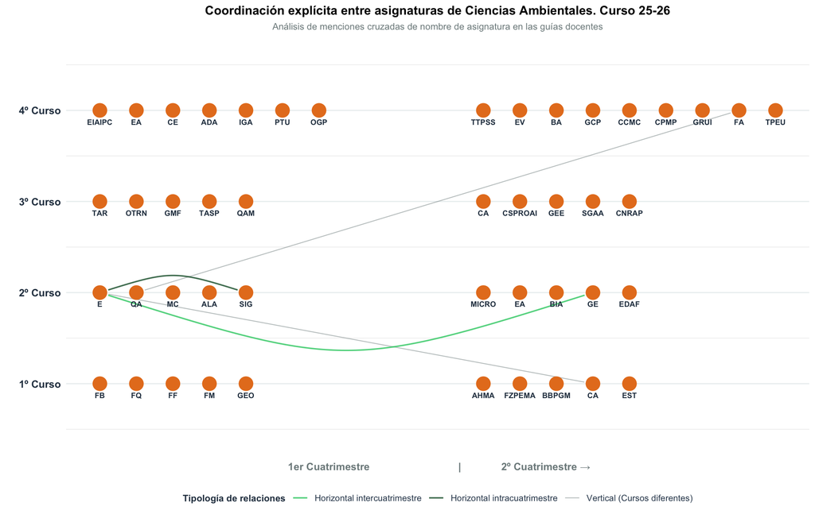

```r
# librerías necesarias (para que se renderice el gráfico bien)
library(tidyverse)
library(tidygraph)
library(ggraph)


# Nos aseguramos de que los códigos sean caracteres puros para evitar desajustes en los joins
nodos_base <- datos_guias %>%
  filter(!is.na(nombre_asignatura)) %>%
  mutate(codigo = as.character(codigo))

aristas_base <- tabla_relaciones_explicitas_verificadas %>%
  mutate(
    codigo_1 = as.character(codigo_1),
    codigo_2 = as.character(codigo_2)
  )

# Rejilla de coordenadas
nodos_posicionados <- nodos_base %>%
  distinct(codigo, sigla, nombre_asignatura, curso, cuatrimestre) %>%
  mutate(
    curso_num = as.numeric(str_extract(curso, "\\d+")),
    cuat_clean = case_when(
      str_detect(tolower(cuatrimestre), "primer|1") ~ 1,
      str_detect(tolower(cuatrimestre), "segundo|2") ~ 2,
      TRUE ~ 1
    ),
    sigla_display = toupper(as.character(sigla))
  ) %>%
  filter(!is.na(curso_num)) %>%
  arrange(curso_num, cuat_clean, codigo) %>%
  group_by(curso_num, cuat_clean) %>%
  mutate(pos_secuencial = row_number()) %>%
  ungroup() %>%
  mutate(
    y_coord = curso_num,
    x_coord = if_else(cuat_clean == 1,
                      pos_secuencial,
                      pos_secuencial + max(pos_secuencial) + 1.5)
  )

# Vinculación geométrica de aristas
aristas_triple_capa <- aristas_base %>%
  select(from = codigo_1, to = codigo_2) %>%
  left_join(nodos_posicionados %>% select(from = codigo, curso_from = curso_num, cuat_from = cuat_clean), by = "from") %>%
  left_join(nodos_posicionados %>% select(to = codigo, curso_to = curso_num, cuat_to = cuat_clean), by = "to") %>%
  filter(!is.na(from) & !is.na(to)) %>%
  mutate(
    tipo_relacion = case_when(
      curso_from != curso_to ~ "Vertical (Cursos diferentes)",
      curso_from == curso_to & cuat_from == cuat_to ~ "Horizontal intracuatrimestre",
      curso_from == curso_to & cuat_from != cuat_to ~ "Horizontal intercuatrimestre",
      TRUE ~ "Vertical (Cursos diferentes)"
    )
  ) %>%
  select(from, to, tipo_relacion)

nodes_final <- nodos_posicionados %>%
  rename(id = codigo)

# Ensamblaje del gráfico
grafo_objeto_final <- tbl_graph(
  nodes = nodes_final,
  edges = aristas_triple_capa,
  directed = FALSE
)

# Renderización del gráfico tanto en el informe de quarto como en pdf

# Creamos el objeto gráfico completo en memoria
mapa_nominal_final <- ggraph(grafo_objeto_final, layout = "manual", x = x_coord, y = y_coord) +
  geom_edge_link(
    aes(filter = (tipo_relacion == "Vertical (Cursos diferentes)"), color = tipo_relacion),
    start_cap = circle(3, 'mm'), end_cap = circle(3, 'mm'), alpha = 0.5, width = 0.4
  ) +
  geom_edge_arc(
    aes(filter = (tipo_relacion == "Horizontal intracuatrimestre"), color = tipo_relacion),
    start_cap = circle(3, 'mm'), end_cap = circle(3, 'mm'), alpha = 0.8, width = 0.66, strength = 0.08
  ) +
  geom_edge_arc(
    aes(filter = (tipo_relacion == "Horizontal intercuatrimestre"), color = tipo_relacion),
    start_cap = circle(3, 'mm'), end_cap = circle(3, 'mm'), alpha = 0.8, width = 0.66, strength = -0.08
  ) +
  geom_node_point(color = "#E67E22", size = 6) +
  geom_node_text(aes(label = sigla_display), vjust = 2.6, size = 2.6, fontface = "bold", color = "#2C3E50") +
  scale_edge_color_manual(
    name = "Tipología de relaciones",
    values = c(
      "Vertical (Cursos diferentes)"   = "#7F8C8D",
      "Horizontal intracuatrimestre"   = "#145A32",
      "Horizontal intercuatrimestre"   = "#2ECC71"
    )
  ) +
  scale_y_continuous(breaks = 1:4, labels = c("1º Curso", "2º Curso", "3º Curso", "4º Curso"), limits = c(0.5, 4.5)) +
  labs(
    title = "Coordinación explícita entre asignaturas de Ciencias Ambientales. Curso 25-26",
    subtitle = "Análisis de menciones cruzadas de nombre de asignatura en las guías docentes",
    x = " 1er Cuatrimestre                               |              2º Cuatrimestre →",
    y = ""
  ) +
  theme_minimal() +
  theme(
    panel.grid.major.x = element_blank(), panel.grid.minor.x = element_blank(),
    panel.grid.major.y = element_line(color = "#EBF0F1", linetype = "solid"),
    axis.text.x = element_blank(), axis.ticks.x = element_blank(),
    axis.title.x = element_text(face = "bold", size = 10, color = "#7F8C8D", margin = margin(t = 12)),
    axis.text.y = element_text(face = "bold", size = 10, color = "#2C3E50"),
    plot.title = element_text(face = "bold", size = 12, hjust = 0.5),
    plot.subtitle = element_text(size = 9, hjust = 0.5, color = "#7F8C8D", margin = margin(b = 15)),
    legend.position = "bottom",
    legend.title = element_text(face = "bold", size = 9, color = "#2C3E50"),
    legend.text = element_text(size = 8.5, color = "#34495E"),
    legend.box = "horizontal",
    panel.background = element_rect(fill = "#FFFFFF", color = NA)
  )

# Aseguramos la existencia de la carpeta de destino para no ensuciar la raíz
carpeta_salida <- "outputs"
if (!dir.exists(carpeta_salida)) dir.create(carpeta_salida, recursive = TRUE)

# Exportación silenciosa a pdf
ggsave(
  filename = file.path(carpeta_salida, "mapa_coordinacion_explicita_CCAA.pdf"),
  plot = mapa_nominal_final,
  width = 11,
  height = 7,
  device = "pdf"
)


# Esto fuerza a knitr a pintar el gráfico en el cuerpo del informe HTML
mapa_nominal_final
```

El gráfico anterior se puede descargar [aquí](https://raw.githubusercontent.com/fjbonet/informe_coordinacion_CCAA_UCO/main/outputs/mapa_coordinacion_explicita_CCAA.pdf) en formato pdf.

Observamos que las únicas relaciones de coordinación explícitamente mencionadas en las guías docentes son las siguientes: + Química ambiental (QA) y Físicoquímica de aguas (FA)

- Sistemas de información geográfica (SIG) y Ecología (E)
- Ecología (E) y Gestión de ecosistemas (GE)
- Ecología (E) y Cartografía aplicada (CA)

## 3.3 Relaciones de dependencia entre asignaturas

Tras el análisis descrito aquí se obtienen una serie de relaciones de dependencia entre asignaturas. Se muestran en la siguiente tabla.

| Sigla dependiente | Asignatura dependiente | Sigla instrumental | Asignatura instrumental |
| --- | --- | --- | --- |
| ADA | ANÁLISIS DE DATOS AMBIENTALES | EST | ESTADÍSTICA |
| CPMP | CONTAMINACIÓN POR METALES PESADOS | QA | QUÍMICA AMBIENTAL |
| CSPROAI | CONTAMINACIÓN DE LOS SUELOS POR RESIDUOS ORGÁNICOS, AGRÍCOLAS E INDUSTRIALES | FB | FUNDAMENTOS DE BIOLOGÍA |
| CSPROAI | CONTAMINACIÓN DE LOS SUELOS POR RESIDUOS ORGÁNICOS, AGRÍCOLAS E INDUSTRIALES | FQ | FUNDAMENTOS DE QUÍMICA |
| CSPROAI | CONTAMINACIÓN DE LOS SUELOS POR RESIDUOS ORGÁNICOS, AGRÍCOLAS E INDUSTRIALES | QA | QUÍMICA AMBIENTAL |
| CSPROAI | CONTAMINACIÓN DE LOS SUELOS POR RESIDUOS ORGÁNICOS, AGRÍCOLAS E INDUSTRIALES | EIAIPC | EVALUACIÓN DE IMPACTO AMBIENTAL: INSTRUMENTOS DE PREVENCIÓN Y CONTROL |
| CSPROAI | CONTAMINACIÓN DE LOS SUELOS POR RESIDUOS ORGÁNICOS, AGRÍCOLAS E INDUSTRIALES | QAM | QUÍMICA ANALÍTICA MEDIOAMBIENTAL |
| CSPROAI | CONTAMINACIÓN DE LOS SUELOS POR RESIDUOS ORGÁNICOS, AGRÍCOLAS E INDUSTRIALES | GEO | GEOLOGÍA |
| CSPROAI | CONTAMINACIÓN DE LOS SUELOS POR RESIDUOS ORGÁNICOS, AGRÍCOLAS E INDUSTRIALES | EDAF | EDAFOLOGÍA |
| GE | GESTIÓN DE ECOSISTEMAS | E | ECOLOGÍA |
| GE | GESTIÓN DE ECOSISTEMAS | SIG | SISTEMAS DE INFORMACIÓN GEOGRÁFICA |
| GEE | GESTIÓN ENERGÉTICA Y ECOEFICIENCIA | CA | CONTAMINACIÓN ATMOSFÉRICA |
| GMF | GESTIÓN DEL MEDIO FÍSICO | OTRN | ORDENACIÓN DEL TERRITORIO Y RIESGOS NATURALES |
| GMF | GESTIÓN DEL MEDIO FÍSICO | GEO | GEOLOGÍA |
| GMF | GESTIÓN DEL MEDIO FÍSICO | EDAF | EDAFOLOGÍA |
| MC | METEOROLOGÍA Y CLIMATOLOGÍA | FF | FUNDAMENTOS DE FÍSICA |
| QAM | QUÍMICA ANALÍTICA MEDIOAMBIENTAL | FQ | FUNDAMENTOS DE QUÍMICA |
| QAM | QUÍMICA ANALÍTICA MEDIOAMBIENTAL | QA | QUÍMICA AMBIENTAL |
| SIG | SISTEMAS DE INFORMACIÓN GEOGRÁFICA | CA | CARTOGRAFÍA APLICADA |
| TPEU | TECNICAS PARA LA EVALUACIÓN URBANA | OTRN | ORDENACIÓN DEL TERRITORIO Y RIESGOS NATURALES |

Y también en el siguiente gráfico que puede descargarse [aquí](https://raw.githubusercontent.com/fjbonet/informe_coordinacion_CCAA_UCO/main/outputs/mapa_dependencias_CCAA.pdf) en formato pdf.

**Mostrar líneas de código R**

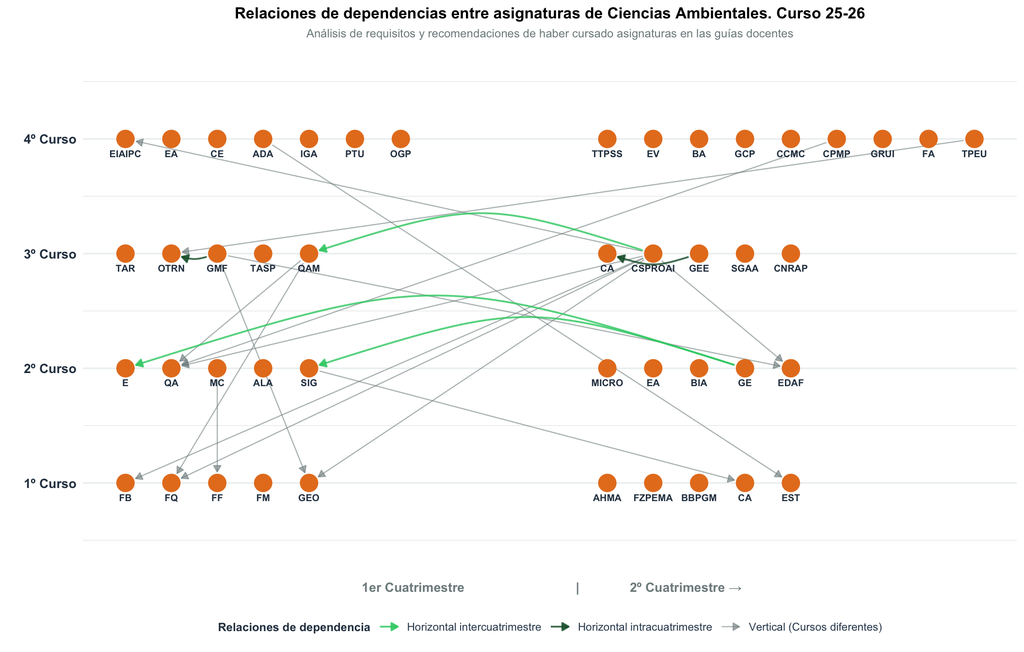

```r
# 1. CARGA LOCAL DE DEPENDENCIAS CRÍTICAS
library(tidyverse)
library(tidygraph)
library(ggraph)

# 2. ENCAPSULACIÓN Y BLINDAJE DE DATOS DE ENTRADA
# Forzamos cadenas de caracteres para blindar los cruces (joins) frente a bloques intermedios
nodos_base_dep <- datos_guias %>%
  filter(!is.na(nombre_asignatura)) %>%
  mutate(codigo = as.character(codigo))

aristas_base_dep <- relaciones_dependencia_detectadas %>%
  mutate(
    codigo_origen  = as.character(codigo_origen),
    codigo_destino = as.character(codigo_destino)
  )

# 3. RECONSTRUCCIÓN DE LA REJILLA DE COORDENADAS (X, Y)
nodos_posicionados_dep <- nodos_base_dep %>%
  distinct(codigo, sigla, nombre_asignatura, curso, cuatrimestre) %>%
  mutate(
    curso_num = as.numeric(str_extract(curso, "\\d+")),
    cuat_clean = case_when(
      str_detect(tolower(cuatrimestre), "primer|1") ~ 1,
      str_detect(tolower(cuatrimestre), "segundo|2") ~ 2,
      TRUE ~ 1
    ),
    sigla_display = toupper(as.character(sigla))
  ) %>%
  filter(!is.na(curso_num)) %>%
  arrange(curso_num, cuat_clean, codigo) %>%
  group_by(curso_num, cuat_clean) %>%
  mutate(pos_secuencial = row_number()) %>%
  ungroup() %>%
  mutate(
    y_coord = curso_num,
    x_coord = if_else(cuat_clean == 1,
                      pos_secuencial,
                      pos_secuencial + max(pos_secuencial) + 1.5)
  )

# 4. ENRUTAMIENTO ASIMÉTRICO DE ARISTAS (DIRECCIÓN DE LA FLECHA)
aristas_dirigidas <- aristas_base_dep %>%
  select(from = codigo_origen, to = codigo_destino) %>%
  left_join(nodos_posicionados_dep %>% select(from = codigo, curso_from = curso_num, cuat_from = cuat_clean), by = "from") %>%
  left_join(nodos_posicionados_dep %>% select(to = codigo, curso_to = curso_num, cuat_to = cuat_clean), by = "to") %>%
  filter(!is.na(from) & !is.na(to)) %>%
  mutate(
    tipo_relacion = case_when(
      curso_from != curso_to ~ "Vertical (Cursos diferentes)",
      curso_from == curso_to & cuat_from == cuat_to ~ "Horizontal intracuatrimestre",
      curso_from == curso_to & cuat_from != cuat_to ~ "Horizontal intercuatrimestre",
      TRUE ~ "Vertical (Cursos diferentes)"
    )
  )

nodes_final_dep <- nodos_posicionados_dep %>%
  rename(id = codigo)

# Ensamblaje del objeto topológico forzando la direccionalidad (directed = TRUE)
grafo_dirigido_final <- tbl_graph(
  nodes = nodes_final_dep,
  edges = aristas_dirigidas,
  directed = TRUE
)

# 5. CONFIGURACIÓN DEL LIENZO Y CONSTRUCCIÓN VECTORIAL DE LA RED
mapa_dependencias_plot <- ggraph(grafo_dirigido_final, layout = "manual", x = x_coord, y = y_coord) +

  # CAPA 1: Dependencias inter-curso -> Rectas con punta de flecha
  geom_edge_link(
    aes(filter = (tipo_relacion == "Vertical (Cursos diferentes)"), color = tipo_relacion),
    # Ajuste milimétrico para que la flecha muera en el borde del círculo naranja (3mm)
    start_cap = circle(3, 'mm'), end_cap = circle(3, 'mm'),
    alpha = 0.6, width = 0.4,
    arrow = arrow(length = unit(2, 'mm'), type = "closed") # Punta de flecha ejecutiva cerrada
  ) +

  # CAPA 2: Dependencias intracuatrimestre -> Arcos superiores con punta de flecha
  geom_edge_arc(
    aes(filter = (tipo_relacion == "Horizontal intracuatrimestre"), color = tipo_relacion),
    start_cap = circle(3, 'mm'), end_cap = circle(3, 'mm'),
    alpha = 0.8, width = 0.66, strength = 0.08,
    arrow = arrow(length = unit(2, 'mm'), type = "closed")
  ) +

  # CAPA 3: Dependencias intercuatrimestre -> Arcos inferiores con punta de flecha
  geom_edge_arc(
    aes(filter = (tipo_relacion == "Horizontal intercuatrimestre"), color = tipo_relacion),
    start_cap = circle(3, 'mm'), end_cap = circle(3, 'mm'),
    alpha = 0.8, width = 0.66, strength = -0.08,
    arrow = arrow(length = unit(2, 'mm'), type = "closed")
  ) +

  # Nodos de asignatura uniformes
  geom_node_point(color = "#E67E22", size = 6) +

  # Siglas de asignaturas (idéntica tipografía y vjust que el mapa anterior)
  geom_node_text(aes(label = sigla_display), vjust = 2.6, size = 2.6, fontface = "bold", color = "#2C3E50") +

  # Asignación de la paleta cromática corporativa
  scale_edge_color_manual(
    name = "Relaciones de dependencia",
    values = c(
      "Vertical (Cursos diferentes)"   = "#7F8C8D",
      "Horizontal intracuatrimestre"   = "#145A32",
      "Horizontal intercuatrimestre"   = "#2ECC71"
    )
  ) +

  scale_y_continuous(breaks = 1:4, labels = c("1º Curso", "2º Curso", "3º Curso", "4º Curso"), limits = c(0.5, 4.5)) +

  labs(
    title = "Relaciones de dependencias entre asignaturas de Ciencias Ambientales. Curso 25-26",
    subtitle = "Análisis de requisitos y recomendaciones de haber cursado asignaturas en las guías docentes",
    x = " 1er Cuatrimestre                               |              2º Cuatrimestre →",
    y = ""
  ) +

  theme_minimal() +
  theme(
    panel.grid.major.x = element_blank(), panel.grid.minor.x = element_blank(),
    panel.grid.major.y = element_line(color = "#EBF0F1", linetype = "solid"),
    axis.text.x = element_blank(), axis.ticks.x = element_blank(),
    axis.title.x = element_text(face = "bold", size = 10, color = "#7F8C8D", margin = margin(t = 12)),
    axis.text.y = element_text(face = "bold", size = 10, color = "#2C3E50"),
    plot.title = element_text(face = "bold", size = 12, hjust = 0.5),
    plot.subtitle = element_text(size = 9, hjust = 0.5, color = "#7F8C8D", margin = margin(b = 15)),
    legend.position = "bottom",
    legend.title = element_text(face = "bold", size = 9, color = "#2C3E50"),
    legend.text = element_text(size = 8.5, color = "#34495E"),
    legend.box = "horizontal",
    panel.background = element_rect(fill = "#FFFFFF", color = NA)
  )

# 6. EXPORTACIÓN PARALELA A LA CARPETA OUTPUTS (PDF VECTORIAL)
carpeta_outputs <- "outputs"
if (!dir.exists(carpeta_outputs)) dir.create(carpeta_outputs, recursive = TRUE)

ggsave(
  filename = file.path(carpeta_outputs, "mapa_dependencias_CCAA.pdf"),
  plot = mapa_dependencias_plot,
  width = 11,
  height = 7,
  device = "pdf"
)

# 7. INVOCACIÓN PARA LA CAPTURA NATIVA DE QUARTO (INFORME HTML)
mapa_dependencias_plot
```

## 3.4 Similitud léxica entre asignaturas del grado

**Mostrar líneas de código R**

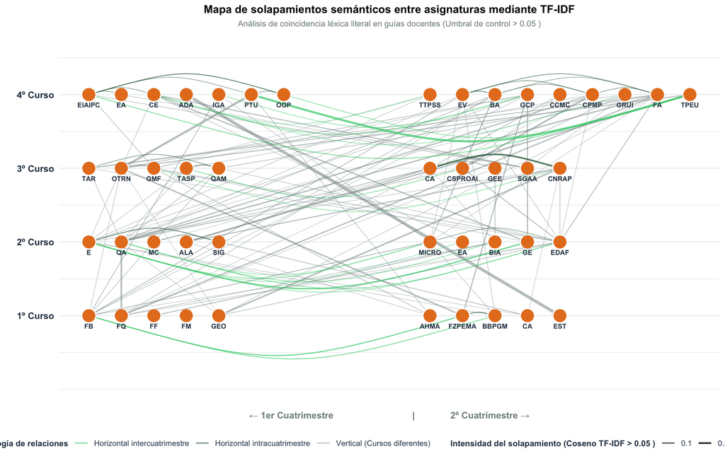

```r
# 1. CARGA LOCAL DE DEPENDENCIAS CRÍTICAS
library(tidyverse)
library(tidygraph)
library(ggraph)


# ==============================================================================
# FASE 7 (TF-IDF): VISUALIZACIÓN DE LA RED DE SOLAPAMIENTO LITERAL (SANEADO)
# ==============================================================================

# 2. ENCAPSULACIÓN Y PARÁMETROS EXPERTOS DE ENTRADA
umbral_tfidf_usuario <- 0.05  #

nodos_base_tfidf <- datos_guias %>%
  filter(!is.na(nombre_asignatura)) %>%
  mutate(codigo = str_trim(as.character(codigo)))

aristas_base_tfidf <- similitud_tfidf_detectada %>%
  # FILTRO DINÁMICO: Evaluamos en base a la variable del usuario
  filter(coseno_tfidf >= umbral_tfidf_usuario) %>%
  mutate(
    codigo_1 = str_trim(as.character(codigo_1)),
    codigo_2 = str_trim(as.character(codigo_2))
  )

# 3. RECONSTRUCCIÓN DE LA REJILLA DE COORDENADAS INTERACTIVA (X, Y)
nodos_posicionados_tfidf <- nodos_base_tfidf %>%
  distinct(codigo, sigla, nombre_asignatura, curso, cuatrimestre) %>%
  mutate(
    curso_num = as.numeric(str_extract(curso, "\\d+")),
    cuat_clean = case_when(
      str_detect(tolower(cuatrimestre), "primer|1") ~ 1,
      str_detect(tolower(cuatrimestre), "segundo|2") ~ 2,
      TRUE ~ 1
    ),
    sigla_display = toupper(as.character(sigla))
  ) %>%
  filter(!is.na(curso_num)) %>%
  arrange(curso_num, cuat_clean, codigo) %>%
  group_by(curso_num, cuat_clean) %>%
  mutate(pos_secuencial = row_number()) %>%
  ungroup() %>%
  mutate(
    y_coord = curso_num,
    x_coord = if_else(cuat_clean == 1,
                      pos_secuencial,
                      pos_secuencial + max(pos_secuencial) + 1.5)
  )

# 4. ENRUTAMIENTO SIMÉTRICO DE ARISTAS SEGÚN CURSO Y CUATRIMESTRE
aristas_simetricas_tfidf <- aristas_base_tfidf %>%
  select(from = codigo_1, to = codigo_2, peso_coseno = coseno_tfidf) %>%

  # Forzamos tipo carácter en las claves de enlace para evitar fallos de coerción
  mutate(
    from = as.character(from),
    to   = as.character(to)
  ) %>%

  # Cruce de coordenadas espaciales basado estrictamente en el CÓDIGO ÚNICO
  left_join(nodos_posicionados_tfidf %>% mutate(codigo = as.character(codigo)) %>%
              select(from = codigo, curso_from = curso_num, cuat_from = cuat_clean), by = "from") %>%
  left_join(nodos_posicionados_tfidf %>% mutate(codigo = as.character(codigo)) %>%
              select(to = codigo, curso_to = curso_num, cuat_to = cuat_clean), by = "to") %>%
  filter(!is.na(curso_from) & !is.na(curso_to)) %>%

  mutate(
    tipo_relacion = case_when(
      curso_from != curso_to ~ "Vertical (Cursos diferentes)",
      curso_from == curso_to & cuat_from == cuat_to ~ "Horizontal intracuatrimestre",
      curso_from == curso_to & cuat_from != cuat_to ~ "Horizontal intercuatrimestre",
      TRUE ~ "Vertical (Cursos diferentes)"
    )
  )

# Ensamblaje del grafo garantizando la integridad de tipos
nodes_final_tfidf <- nodos_posicionados_tfidf %>%
  rename(id = codigo) %>%
  mutate(id = as.character(id))

grafo_tfidf_final <- tbl_graph(
  nodes = nodes_final_tfidf,
  edges = aristas_simetricas_tfidf,
  directed = FALSE
)

# ==============================================================================
# 5. CONSTRUCCIÓN VECTORIAL DEL MAPA SEMÁNTICO (CON GROSOR PROPORCIONAL)
# ==============================================================================
mapa_tfidf_plot <- ggraph(grafo_tfidf_final, layout = "manual", x = x_coord, y = y_coord) +

  # CAPA 1: Relaciones inter-curso -> Mapeo dinámico de edge_width
  geom_edge_link(
    aes(filter = (tipo_relacion == "Vertical (Cursos diferentes)"),
        color = tipo_relacion,
        edge_width = peso_coseno),
    start_cap = circle(3, 'mm'), end_cap = circle(3, 'mm'),
    alpha = 0.5
  ) +

  # CAPA 2: Relaciones intracuatrimestre -> Mapeo dinámico de edge_width (Arcos superiores)
  geom_edge_arc(
    aes(filter = (tipo_relacion == "Horizontal intracuatrimestre"),
        color = tipo_relacion,
        edge_width = peso_coseno),
    start_cap = circle(3, 'mm'), end_cap = circle(3, 'mm'),
    alpha = 0.7, strength = 0.08
  ) +

  # CAPA 3: Relaciones intercuatrimestre -> Mapeo dinámico de edge_width (Arcos inferiores)
  geom_edge_arc(
    aes(filter = (tipo_relacion == "Horizontal intercuatrimestre"),
        color = tipo_relacion,
        edge_width = peso_coseno),
    start_cap = circle(3, 'mm'), end_cap = circle(3, 'mm'),
    alpha = 0.7, strength = -0.08
  ) +

  # Capa de Nodos: Geometría fija uniforme
  geom_node_point(color = "#E67E22", size = 6) +

  # Etiquetas mnemotécnicas (Inmunes a duplicaciones en el lienzo)
  geom_node_text(aes(label = sigla_display), vjust = 2.6, size = 2.6, fontface = "bold", color = "#2C3E50") +

  # Paleta cromática corporativa (Sincronizada con el mapa LSA para mantener consistencia)
  scale_edge_color_manual(
    name = "Tipología de relaciones",
    values = c(
      "Vertical (Cursos diferentes)"   = "#7F8C8D",
      "Horizontal intracuatrimestre"   = "#145A32",
      "Horizontal intercuatrimestre"   = "#2ECC71"
    )
  ) +

# CONFIGURACIÓN ESCALADA DEL GROSOR (Sincronizada dinámicamente)
  scale_edge_width_continuous(
    name = paste("Intensidad del solapamiento (Coseno TF-IDF >", umbral_tfidf_usuario, ")"),
    range = c(0.2, 1.5)
  ) +

  scale_y_continuous(breaks = 1:4, labels = c("1º Curso", "2º Curso", "3º Curso", "4º Curso"), limits = c(0.1, 4.5)) +

  labs(
    title = "Mapa de solapamientos semánticos entre asignaturas mediante TF-IDF",
    subtitle = paste("Análisis de coincidencia léxica literal en guías docentes (Umbral de control >", umbral_tfidf_usuario, ")"),
    x = "← 1er Cuatrimestre                               |              2º Cuatrimestre →",
    y = ""
  ) +

  theme_minimal() +
  theme(
    panel.grid.major.x = element_blank(), panel.grid.minor.x = element_blank(),
    panel.grid.major.y = element_line(color = "#EBF0F1", linetype = "solid"),
    axis.text.x = element_blank(), axis.ticks.x = element_blank(),
    axis.title.x = element_text(face = "bold", size = 10, color = "#7F8C8D", margin = margin(t = 12)),
    axis.text.y = element_text(face = "bold", size = 10, color = "#2C3E50"),
    plot.title = element_text(face = "bold", size = 12, hjust = 0.5),
    plot.subtitle = element_text(size = 9, hjust = 0.5, color = "#7F8C8D", margin = margin(b = 15)),
    legend.position = "bottom",
    legend.title = element_text(face = "bold", size = 9, color = "#2C3E50"),
    legend.text = element_text(size = 8.5, color = "#34495E"),
    legend.box = "horizontal",
    panel.background = element_rect(fill = "#FFFFFF", color = NA)
  )

# 6. EXPORTACIÓN SILENCIOSA A LA CARPETA OUTPUTS (PDF VECTORIAL)
carpeta_outputs <- "outputs"
if (!dir.exists(carpeta_outputs)) dir.create(carpeta_outputs, recursive = TRUE)

ggsave(
  filename = file.path(carpeta_outputs, "mapa_similitud_tfidf_CCAA.pdf"),
  plot = mapa_tfidf_plot,
  width = 11,
  height = 7,
  device = "pdf"
)

# 7. INVOCACIÓN DE RETORNO PARA EL REPOSITORIO DE QUARTO (HTML)
mapa_tfidf_plot
```

## 3.5 Convergencia semántica latente entre asignaturas del grado

**Mostrar líneas de código R**

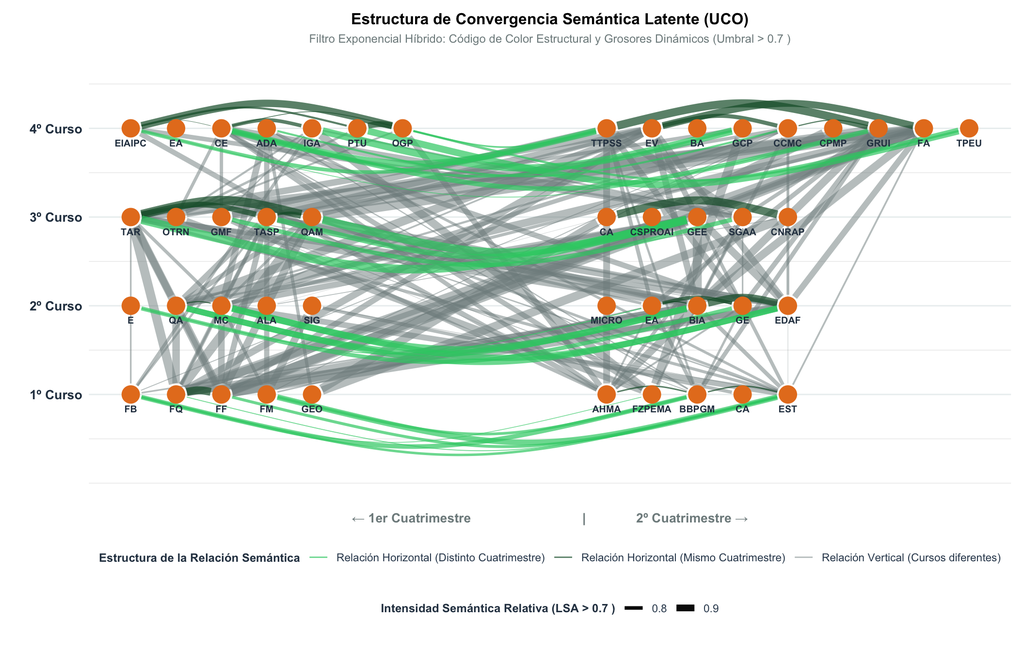

```r
library(tidyverse)
library(tidygraph)
library(ggraph)

# ==============================================================================
# FASE 7: VISUALIZACIÓN DE LA RED DE CONVERGENCIA SEMÁNTICA (CORREGIDO)
# ==============================================================================

# 1. ESTABILIZACIÓN DE LOS NODOS (REJILLA ESPACIAL INVARIABLE)
nodos_posicionados <- datos_guias %>%
  filter(!is.na(nombre_asignatura)) %>%
  distinct(codigo, sigla, nombre_asignatura, curso, cuatrimestre) %>%
  mutate(
    curso_num = as.numeric(str_extract(curso, "\\d+")),
    cuat_clean = case_when(
      str_detect(tolower(cuatrimestre), "primer|1") ~ 1,
      str_detect(tolower(cuatrimestre), "segundo|2") ~ 2,
      TRUE ~ 1
    ),
    sigla_display = toupper(as.character(sigla))
  ) %>%
  filter(!is.na(curso_num)) %>%
  arrange(curso_num, cuat_clean, codigo) %>%
  group_by(curso_num, cuat_clean) %>%
  mutate(pos_secuencial = row_number()) %>%
  ungroup() %>%
  mutate(
    y_coord = curso_num,
    x_coord = if_else(cuat_clean == 1,
                      pos_secuencial,
                      pos_secuencial + max(pos_secuencial) + 1.5)
  )

# 2. FILTRADO Y CLASIFICACIÓN GEOMÉTRICA DE ARISTAS (ENLACE POR CÓDIGO ÚNICO)
umbral_usuario <- 0.7  # Ajustado de forma determinista a tu nuevo nivel de exigencia

aristas_semanticas <- tabla_relaciones_semanticas %>%
  # Cortafuegos de densidad LSA
  filter(similitud_lsa > umbral_usuario) %>%

  # SOLUCIÓN CRÍTICA: Asignamos origen y destino utilizando los códigos limpios ya presentes
  mutate(
    from = as.character(codigo_A),
    to   = as.character(codigo_B)
  ) %>%

  # Cruzamos coordenadas espaciales para determinar trayectorias en base al CÓDIGO
  left_join(nodos_posicionados %>% mutate(codigo = as.character(codigo)) %>%
              select(from = codigo, curso_from = curso_num, cuat_from = cuat_clean), by = "from") %>%
  left_join(nodos_posicionados %>% mutate(codigo = as.character(codigo)) %>%
              select(to = codigo, curso_to = curso_num, cuat_to = cuat_clean), by = "to") %>%
  filter(!is.na(curso_from) & !is.na(curso_to)) %>%

  # Mapeo exacto de las etiquetas para la leyenda semántico-cromática
  mutate(
    tipo_relacion = case_when(
      curso_from != curso_to ~ "Relación Vertical (Cursos diferentes)",
      curso_from == curso_to & cuat_from == cuat_to ~ "Relación Horizontal (Mismo Cuatrimestre)",
      curso_from == curso_to & cuat_from != cuat_to ~ "Relación Horizontal (Distinto Cuatrimestre)",
      TRUE ~ "Relación Vertical (Cursos diferentes)"
    )
  ) %>%
  select(from, to, similitud_lsa, tipo_relacion)

# 3. ENSAMBLAJE DEL GRAFO MATRICIAL HÍBRIDO
nodes_final <- nodos_posicionados %>%
  rename(id = codigo) %>%
  mutate(id = as.character(id)) # Forzamos tipo carácter para consistencia con edges

grafo_semantico <- tbl_graph(
  nodes = nodes_final,
  edges = aristas_semanticas,
  directed = FALSE
)

# ----------------------------------------------------------------------------
# 4. RENDERIZACIÓN CON INTEGRACIÓN DE COLOR VECTORIAL Y GROSOR EXPANSIVO
# ----------------------------------------------------------------------------
diagrama_semantico_final <- ggraph(grafo_semantico, layout = "manual", x = x_coord, y = y_coord) +

  # CAPA 1: Relaciones entre cursos diferentes -> Rectas y grises
  geom_edge_link(
    aes(filter = (tipo_relacion == "Relación Vertical (Cursos diferentes)"),
        color = tipo_relacion, width = similitud_lsa),
    alpha = 0.5,
    start_cap = circle(3, 'mm'), end_cap = circle(3, 'mm')
  ) +

  # CAPA 2: Horizontales mismo curso e INTRACUATRIMESTRE -> Arcos por ARRIBA y Verde Oscuro
  geom_edge_arc(
    aes(filter = (tipo_relacion == "Relación Horizontal (Mismo Cuatrimestre)"),
        color = tipo_relacion, width = similitud_lsa),
    alpha = 0.7, strength = 0.08,
    start_cap = circle(3, 'mm'), end_cap = circle(3, 'mm')
  ) +

  # CAPA 3: Horizontales mismo curso e INTERCUATRIMESTRE -> Arcos por ABAJO y Verde Claro
  geom_edge_arc(
    aes(filter = (tipo_relacion == "Relación Horizontal (Distinto Cuatrimestre)"),
        color = tipo_relacion, width = similitud_lsa),
    alpha = 0.7, strength = -0.08,
    start_cap = circle(3, 'mm'), end_cap = circle(3, 'mm')
  ) +

  # Nodos monocolor naranja académico uniforme
  geom_node_point(
    color = "#E67E22",
    size = 6
  ) +

  # Rotulación mnemotécnica en mayúsculas estricta debajo del nodo
  geom_node_text(
    aes(label = sigla_display),
    vjust = 2.6, size = 2.6, fontface = "bold", color = "#2C3E50"
  ) +

  # ASIGNACIÓN DE COLORES SOLICITADOS (+5% de contraste en verde interno)
  scale_edge_color_manual(
    name = "Estructura de la Relación Semántica",
    values = c(
      "Relación Vertical (Cursos diferentes)"        = "#7F8C8D", # Gris medio técnico
      "Relación Horizontal (Mismo Cuatrimestre)"     = "#145A32", # Verde oscuro profundo
      "Relación Horizontal (Distinto Cuatrimestre)"  = "#2ECC71"  # Verde claro brillante
    )
  ) +

  # ESCALA DE GROSORES: Mantener reescalado dinámico local maximizado (0.1 a 3.5 mm)
  scale_edge_width_continuous(
    name = paste("Intensidad Semántica Relativa (LSA >", umbral_usuario, ")"),
    range = c(0.1, 3.5)
  ) +

  # SOLUCIÓN LIENZO INFERIOR: Límite expandido a 0.1 para salvar los arcos descendentes de 1º año
  scale_y_continuous(
    breaks = 1:4, labels = c("1º Curso", "2º Curso", "3º Curso", "4º Curso"),
    limits = c(0.1, 4.5)
  ) +

  labs(
    title = "Estructura de Convergencia Semántica Latente (UCO)",
    subtitle = paste("Filtro Exponencial Híbrido: Código de Color Estructural y Grosores Dinámicos (Umbral >", umbral_usuario, ")"),
    x = "← 1er Cuatrimestre                               |              2º Cuatrimestre →",
    y = ""
  ) +

  theme_minimal() +
  theme(
    panel.grid.major.x = element_blank(), panel.grid.minor.x = element_blank(),
    panel.grid.major.y = element_line(color = "#EBF0F1", linetype = "solid"),
    axis.text.x = element_blank(), axis.ticks.x = element_blank(),
    axis.title.x = element_text(face = "bold", size = 10, color = "#7F8C8D", margin = margin(t = 12)),
    axis.text.y = element_text(face = "bold", size = 10, color = "#2C3E50"),
    plot.title = element_text(face = "bold", size = 12, hjust = 0.5),
    plot.subtitle = element_text(size = 9, hjust = 0.5, color = "#7F8C8D", margin = margin(b = 15)),

    # Colchón de aire perimetral para evitar recortes en la exportación
    plot.margin = margin(t = 10, r = 10, b = 20, l = 10, unit = "pt"),

    # Configuración de la doble leyenda integrada en la base (Color + Grosor)
    legend.position = "bottom",
    legend.box = "vertical",
    legend.title = element_text(face = "bold", size = 9, color = "#2C3E50"),
    legend.text = element_text(size = 8.5, color = "#34495E"),
    panel.background = element_rect(fill = "#FFFFFF", color = NA)
  )

# 6. EXPORTACIÓN SILENCIOSA A LA CARPETA OUTPUTS (PDF VECTORIAL)
carpeta_outputs <- "outputs"
if (!dir.exists(carpeta_outputs)) dir.create(carpeta_outputs, recursive = TRUE)

ggsave(
  filename = file.path(carpeta_outputs, "mapa_similitud_lsa.pdf"),
  plot = diagrama_semantico_final,
  width = 11,
  height = 7,
  device = "pdf"
)

# 7. INVOCACIÓN DE RETORNO PARA EL REPOSITORIO DE QUARTO (HTML)
diagrama_semantico_final
```

## 3.6 Caracterización de las relaciones entre asignaturas en función de potenciales necesidades de coordinación

Aquí estaría guay hacer una tabla final que sintetizara los valores de cada relación entre asignaturas para cada uno de los índices que hemos creado.

- Coordinación explícita. Binario.Sí-NO. `tabla_relaciones_explicitas_verificadas`
- RElación de dependencia. Binario. Sí-No. `relaciones_dependencia_detectada`
- Similitud según TF-ID. Continuo. `similitud_tfidf_detectada`
- Similitud según LSA. Continuo `tabla_relaciones_semanticas`

A estos valores aplicamos las reglas heurísticas que hemos inventado. Quizás se puede aplicar también la lógica difusa y asignar porcentages de pertenencia de cada relación a los distintos tipos de asignaturasd…

**Mostrar líneas de código R**

```r
# ==============================================================================
# Crea matriz para heatmap
# ==============================================================================

library(tidyverse)

# 1. Calculamos el IAC continuo para cada par único de asignaturas
matriz_iac_longitudinal <- matriz_maestra_particion %>%
  mutate(
    iac = (1.5 * u_solapamiento_diacronico) +
          (1.0 * u_solapamiento_sincronico) -
          (0.5 * u_confluencia)
  ) %>%
  select(codigo_1, codigo_2, iac)

# 2. Espejamos la tabla para que sea simétrica (aristas de ida y vuelta)
matriz_iac_espejada <- bind_rows(
  matriz_iac_longitudinal,
  matriz_iac_longitudinal %>% rename(codigo_1 = codigo_2, codigo_2 = codigo_1)
) %>%
  distinct(codigo_1, codigo_2, .keep_all = TRUE)

# 3. Pivotamos a una matriz cuadrada estricta (Asignaturas x Asignaturas)
matriz_cuadrada_heatmap <- matriz_iac_espejada %>%
  pivot_wider(names_from = codigo_2, values_from = iac, values_fill = 0) %>%
  column_to_rownames("codigo_1") %>%
  as.matrix()

# Aseguramos que la diagonal principal (auto-coincidencia) esté limpia en 0
diag(matriz_cuadrada_heatmap) <- 0

cat("Matriz de defusificación IAC completada. Dimensiones cuadradas:", dim(matriz_cuadrada_heatmap), "\n")
```

```
Matriz de defusificación IAC completada. Dimensiones cuadradas: 46 46
```

**Mostrar líneas de código R**

```r
# ==============================================================================
# VISUALIZACIÓN TRIANGULAR OPTIMIZADA: SÓLO SIGLAS CON EXPORTACIÓN A PDF (CORREGIDO)
# ==============================================================================

library(tidyverse)
library(pheatmap)

# ------------------------------------------------------------------------------
# 1. Preparación de Etiquetas de Siglas Únicas (Evita nombres duplicados)
# ------------------------------------------------------------------------------
dicc_etiquetas <- matriz_maestra_particion %>%
  select(codigo_1, sigla_1) %>%
  distinct(codigo_1, .keep_all = TRUE) %>%
  mutate(
    codigo_clean = str_trim(as.character(codigo_1)),
    sigla_clean  = str_trim(as.character(sigla_1))
  )

# ------------------------------------------------------------------------------
# 2. Sincronización Avanzada del Clustering Jerárquico (Ward.D2)
# ------------------------------------------------------------------------------
distancias_hclust <- dist(matriz_cuadrada_heatmap, method = "euclidean")
arbol_jerarquico  <- hclust(distancias_hclust, method = "ward.D2")

# Extraemos el orden exacto de los códigos según el dendrograma
orden_cluster <- arbol_jerarquico$order
asignaturas_ordenadas <- rownames(matriz_cuadrada_heatmap)[orden_cluster]

# Reordenamos la matriz original en ambos ejes SIMÉTRICAMENTE en frío
matriz_ordenada <- matriz_cuadrada_heatmap[asignaturas_ordenadas, asignaturas_ordenadas]

# ------------------------------------------------------------------------------
# 3. Aplicación de la Máscara Triangular (Ocultar Mitad Superior + Diagonal)
# ------------------------------------------------------------------------------
matriz_triangular <- matriz_ordenada
matriz_triangular[upper.tri(matriz_triangular, diag = TRUE)] <- NA

# ------------------------------------------------------------------------------
# 4. Inyección de Siglas Puras con Cortafuegos de Duplicados (SINTAXIS CORREGIDA)
# ------------------------------------------------------------------------------
siglas_limpias <- map_chr(rownames(matriz_triangular), function(cod) {
  # Corregido de %&% a %>% para la correcta evaluación en dplyr
  match_sigla <- dicc_etiquetas %>% filter(codigo_clean == cod) %>% pull(sigla_clean)

  if (length(match_sigla) == 0 || is.na(match_sigla) || match_sigla == "") {
    return(cod)
  } else {
    return(match_sigla)
  }
})

# Hacemos que las siglas sean unívocas para evitar errores por claves repetidas
siglas_unicas <- make.unique(siglas_limpias, sep = ".")

# Asignamos las siglas limpias a ambos ejes de la matriz triangular
rownames(matriz_triangular) <- siglas_unicas
colnames(matriz_triangular) <- siglas_unicas

# ------------------------------------------------------------------------------
# 5. Sincronización Estricta de las Anotaciones Laterales
# ------------------------------------------------------------------------------
anotaciones_df <- datos_guias_inicial %>%
  mutate(codigo_clean = str_trim(as.character(codigo))) %>%
  filter(codigo_clean %in% asignaturas_ordenadas) %>%
  distinct(codigo_clean, curso, cuatrimestre) %>%
  mutate(
    Curso        = paste0(curso, "º Curso"),
    Cuatrimestre = case_when(
      str_detect(tolower(cuatrimestre), "primer|1") ~ "1er Cuat.",
      str_detect(tolower(cuatrimestre), "segundo|2") ~ "2º Cuat.",
      TRUE ~ "Anual"
    )
  )

# Construimos las anotaciones indexando exactamente por las siglas únicas ordenadas
anotaciones_listas <- tibble(codigo_clean = asignaturas_ordenadas, etiqueta = siglas_unicas) %>%
  left_join(anotaciones_df, by = "codigo_clean") %>%
  select(etiqueta, Curso, Cuatrimestre) %>%
  column_to_rownames("etiqueta")

# ------------------------------------------------------------------------------
# 6. Configuración de Paletas Estéticas Generales
# ------------------------------------------------------------------------------
colores_matriz <- colorRampPalette(c("#1F618D", "#FFFFFF", "#C0392B"))(100)

colores_anotaciones <- list(
  Curso = c("1º Curso" = "#BDC3C7", "2º Curso" = "#95A5A6",
            "3º Curso" = "#7F8C8D", "4º Curso" = "#34495E"),
  Cuatrimestre = c("1er Cuat." = "#AED6F1", "2º Cuat." = "#F9E79F", "Anual" = "#D5F5E3")
)

# ------------------------------------------------------------------------------
# 7. EXPORTACIÓN AUTOMÁTICA A PDF (Salida Vectorial para Informe Técnico)
# ------------------------------------------------------------------------------
if (!dir.exists("outputs")) dir.create("outputs", recursive = TRUE)

pheatmap(
  mat = matriz_triangular,
  color = colores_matriz,
  breaks = seq(-0.30, 0.60, length.out = 101),
  border_color = "#EBF0F1",
  cluster_rows = FALSE,
  cluster_cols = FALSE,
  show_rownames = TRUE,
  show_colnames = TRUE,
  fontsize_row = 7.5,
  fontsize_col = 7.5,
  angle_col = 90,
  annotation_row = anotaciones_listas,
  annotation_colors = colores_anotaciones,
  na_col = "#FAFAFA",
  main = "Diagnóstico Curricular de Ciencias Ambientales (UCO) - Vista Triangular",

  filename = "outputs/heatmap_triangular_siglas.pdf",
  width = 11,
  height = 9
)

# ------------------------------------------------------------------------------
# 8. RENDERIZADO EN PANTALLA / INTERACTIVO (Para visualización en Quarto HTML)
# ------------------------------------------------------------------------------
pheatmap(
  mat = matriz_triangular,
  color = colores_matriz,
  breaks = seq(-0.30, 0.60, length.out = 101),
  border_color = "#EBF0F1",
  cluster_rows = FALSE,
  cluster_cols = FALSE,
  show_rownames = TRUE,
  show_colnames = TRUE,
  fontsize_row = 7.5,
  fontsize_col = 7.5,
  angle_col = 90,
  annotation_row = anotaciones_listas,
  annotation_colors = colores_anotaciones,
  na_col = "#FAFAFA",
  main = "Diagnóstico Curricular de Ciencias Ambientales (UCO) - Vista Triangular"
)
```

[output not shown]

# 4 Discusión

# 5 Propuestas para mejorar la coordinación del grado

# 6 Uso de la IA en este análisis

Reflexión sobre cómo he usado esta herramienta. + Me ha permitido hacer análisis que de otra forma habrían sido imposibles.

- Decir que hemos combinado dos IAs de varias formas.
  - Gemini ha sido el motor principal para generar el código de R
  - La construcción del modelo conceptual teórico del análisis semántico se ha hecho combinando Gemini y Claude. Los resultados propuestos por Gemini fueron enviados a Claude para su crítica. La devolución de esta última herramienta se integró en Gemini. Tras varios procesos iterativos se llegó a un marco conceptual sólido que es el que se transformó a Código con Gemini.
- he aprendido muchas cosas: filosofía del tidyverse, comprensión más profunda de los bucles, técnicas de web scrapping, técnicas de análisis semánticos de textos, métodos evaluación de curricula, sobre coordinación de docencia en la universidad
- Lo anterior ha sido posible porque partía de cierto conocimiento previo:
  - Profundo conocimiento sobre bases de datos relacionales.
  - Conocimiento básico sobre R y programación.
  - Conocimiento básico sobre análisis semántico